# Start-codon refinement

This notebook supports the Results section “Start-codon refinement” (`../manuscript/sections/results_start_refinement.tex`) and the subsection “Start-codon refinement” of the Methods (`../manuscript/sections/methods_algorithm.tex`, `sec:start`). It draws Fig. 3 (`fig3_start`), Supplementary Fig. S1 (`figS1_kozak_logos`) and Supplementary Fig. S2 (`figS2_start_grid`). Provenance: E13 (parameter grid, open 5′ ends, GM12878 grid, Kozak score distributions), E09 (releases, PWM seeds, Kozak models, later ATGs), E07 (benchmark summary: v6.0.0 and development runs) and E25 (final release runs) and E29 (5′-open starts and the UTR-length prior).

**Which runs.** The comparisons of refinement settings (no refinement, $w=0$, the $\alpha \times w$ grid) exist only for the development code of the parameter grid (PyTD 48c870c; E13). Its default cell (`a0.4_w25`) gives predictions identical to `pytd_dev_v2`. There is no release run without refinement or without the Kozak term, so these comparisons stay on the grid. They are controlled: within an input, all grid cells have the same predicted stops (E13 checks). Where a final-release equivalent exists, it is used: the comparison with v6.0.0 and the exact F1 of *C. reinhardtii* use the release run `pytd_v7` (`data/benchmark/final_v7/all_scores.tsv`), the per-transcriptome coding scale $\mu$ and the self-trained Kozak models come from the `pytd_v7` runs. The grid used the Kozak weight in nats (25 per nat = 17.3 per bit); the release uses 17 per bit (E13 addendum: exact F1 within 0.0003 on every input).

Data:

- `data/start_param_sensitivity/`: `open_end_mix.tsv`, `grid_scores.tsv`, `optima.tsv`, `plateau.tsv`, `loo.tsv`, `kozak_score_distribution.tsv`, `gm12878.tsv`, `checks.tsv` (E13).
- `data/benchmark/summary.tsv`: `perl_td_v600` (v6.0.0), `pytd` (fixed PWM), `pytd_dev`, `pytd_dev_pwm` (E07, E09).
- `data/benchmark/final_v7/all_scores.tsv`: `pytd_v7` (release; E25).
- `data/start_refinement/` (written by `../pipeline/derive/03_start_refinement.py`): `kozak_models.tsv` (self-trained Kozak counts of the `pytd_v7` runs on `complete`, and models trained on annotated starts), `training_mu.tsv` ($\mu$ and Kozak training starts from the `pytd_v7` logs), `later_atg.tsv` (position of the annotated start among in-frame ATGs) and `seed_start_changes.tsv` (v6.0.0-era PWM seeds on the sample data).
- `data/start_refinement/utr_prior/` (written by `pipeline/derive/03_utr_*.py`; E29): error anatomy and decisions by distance on the release runs (`release.*`, `release_gm12878.*`), annotated 5′ UTR lengths and cut-model distances (`annotation_utr5_summary.tsv`, `trunc_d_summary.tsv`), GM12878 truncation (`gm12878_five_prime_truncation.tsv`) and the UTR-length prior runs (`utr_prior_eval.*.tsv`).
- `figures/kozak/kozak_stats.tsv`: the earlier Kozak statistics (from the `perl_td` training sets), for comparison.

```r
SP <- function(f) read_tab("start_param_sensitivity", f)
open_mix <- SP("open_end_mix.tsv")
grid <- SP("grid_scores.tsv")
optima <- SP("optima.tsv")
plateau <- SP("plateau.tsv")
loo <- SP("loo.tsv")
kdist <- SP("kozak_score_distribution.tsv")
gm <- SP("gm12878.tsv")
gchecks <- SP("checks.tsv")
summ <- read_tab("benchmark", "summary.tsv")
v7 <- read_tab("benchmark", "final_v7", "all_scores.tsv") %>% filter(tool == "pytd_v7")
kmod <- read_tab("start_refinement", "kozak_models.tsv") %>%   # positions -6..-1, +4, +5 (read as numbers)
  mutate(position = ifelse(as.numeric(position) > 0, paste0("+", as.numeric(position)), as.character(position)))
mu <- read_tab("start_refinement", "training_mu.tsv")
later <- read_tab("start_refinement", "later_atg.tsv")
seeds <- read_tab("start_refinement", "seed_start_changes.tsv")
kstats_old <- readr::read_tsv(file.path(REPO, "figures", "kozak", "kozak_stats.tsv"), show_col_types = FALSE)

ALPHAS <- c(0, 0.1, 0.2, 0.3, 0.4, 0.5, 0.6, 0.8, 1, 1.25, 1.5, 2, 3)
W_NATS <- c(0, 5, 10, 25, 50, 100)
w_bits <- function(w) ifelse(w * log(2) >= 10 | w == 0, sprintf("%.0f", w * log(2)), sprintf("%.1f", w * log(2)))
INPUTS <- c("complete", "fragments")
pts <- function(x) 100 * x                       # F1 difference in percentage points
f1p <- function(x) formatC(x, format = "f", digits = 1)

# per organism and input: exact F1 without refinement, w = 0, grid default, v6.0.0, release
f1 <- expand_grid(org = ORGS, input = INPUTS) %>%
  left_join(optima %>% select(org, input, norefine = norefine_f1), by = c("org", "input")) %>%
  left_join(grid %>% filter(config == "a0.4_w0") %>% select(org, input, w0 = f1_exact), by = c("org", "input")) %>%
  left_join(grid %>% filter(config == "a0.4_w25") %>% select(org, input, final = f1_exact,
                                                              final_tp = tp_exact, final_stop = f1_stop),
            by = c("org", "input")) %>%
  left_join(summ %>% filter(tool == "perl_td_v600") %>%
              select(org, input = variant, v600 = f1_exact, v600_tp = tp_exact, v600_stop = f1_stop),
            by = c("org", "input")) %>%
  left_join(v7 %>% select(org, input = variant, release = f1_exact, release_tp = tp_exact,
                          release_stop = f1_stop, release_sens = sensitivity_exact),
            by = c("org", "input"))
stopifnot(!anyNA(f1))
```

The grid’s default cell is the development default (`pytd_dev_v2`) on all 16 inputs, and predicted stops do not change with the refinement settings:

```r
kable(gchecks)
```

| org | input | n_configs | default_preds_identical_to_pytd_dev_v2 | n_pred_values | tp_stop_values | stop_invariant_over_refining_configs | stop_invariant_incl_norefine |
| --- | --- | --- | --- | --- | --- | --- | --- |
| athal | complete | 79 | TRUE | 25595 | 25541 | TRUE | TRUE |
| athal | fragments | 79 | TRUE | 20104 | 20030 | TRUE | TRUE |
| creinhardtii | complete | 79 | TRUE | 16640 | 16590 | TRUE | TRUE |
| creinhardtii | fragments | 79 | TRUE | 14741 | 14686 | TRUE | TRUE |
| dmel | complete | 79 | TRUE | 13189 | 13158 | TRUE | TRUE |
| dmel | fragments | 79 | TRUE | 10929 | 10893 | TRUE | TRUE |
| human | complete | 79 | TRUE | 18816 | 18772 | TRUE | TRUE |
| human | fragments | 79 | TRUE | 16603 | 16532 | TRUE | TRUE |
| mouse | complete | 79 | TRUE | 20925 | 20826 | TRUE | TRUE |
| mouse | fragments | 79 | TRUE | 18161 | 18033 | TRUE | TRUE |
| pfalciparum | complete | 79 | TRUE | 5124 | 5123 | TRUE | TRUE |
| pfalciparum | fragments | 79 | TRUE | 4276 | 4276 | TRUE | TRUE |
| spombe | complete | 79 | TRUE | 4919 | 4919 | TRUE | TRUE |
| spombe | fragments | 79 | TRUE | 4091 | 4089 | TRUE | TRUE |
| tthermophila | complete | 79 | TRUE | 24858 | 24129 | TRUE | TRUE |
| tthermophila | fragments | 79 | TRUE | 22199 | 21794 | TRUE | TRUE |

```r
stopifnot(all(gchecks$default_preds_identical_to_pytd_dev_v2), all(gchecks$stop_invariant_incl_norefine))
```

## Open 5′ ends are common, and their cause depends on the input

Predictions without refinement (grid run `norefine`). An ORF with an open 5′ end whose stop matches a reference CDS is either *truncated* (the reference start is not in the transcript) or a *UTR extension* (the reference start lies downstream of the open end). `other` is neither (543 complete, 563 fragments) and is left out of the fractions.

```r
oe_all <- open_mix %>% filter(org == "ALL")
oe_c <- oe_all %>% filter(input == "complete")
oe_f <- oe_all %>% filter(input == "fragments")
oe <- open_mix %>% filter(org != "ALL") %>%
  mutate(trunc_frac = truncated / (truncated + utr_extended))
oe_frag <- oe %>% filter(input == "fragments")
frag_trunc <- oe_f$truncated / (oe_f$truncated + oe_f$utr_extended)
tth <- oe_frag$trunc_frac[oe_frag$org == "tthermophila"]
pfa <- oe_frag$trunc_frac[oe_frag$org == "pfalciparum"]
stopifnot(sum(oe$truncated[oe$input == "complete"]) == 0,
          min(oe_frag$trunc_frac) == tth, max(oe_frag$trunc_frac) == pfa)
kable(open_mix %>% mutate(trunc_frac = round(truncated / (truncated + utr_extended), 3)),
      caption = "Open 5′ ends without refinement (Fig. 3a plots trunc_frac)")
```

Open 5′ ends without refinement (Fig. 3a plots trunc_frac)

| org | input | n_pred | open_5prime | truncated | utr_extended | other | truncated_frac | trunc_frac |
| --- | --- | --- | --- | --- | --- | --- | --- | --- |
| athal | complete | 25595 | 7499 | 0 | 7468 | 31 | 0.000 | 0.000 |
| creinhardtii | complete | 16640 | 4069 | 0 | 4048 | 21 | 0.000 | 0.000 |
| dmel | complete | 13189 | 2677 | 0 | 2670 | 7 | 0.000 | 0.000 |
| human | complete | 18816 | 7907 | 0 | 7870 | 37 | 0.000 | 0.000 |
| mouse | complete | 20925 | 5418 | 0 | 5386 | 32 | 0.000 | 0.000 |
| pfalciparum | complete | 5124 | 214 | 0 | 214 | 0 | 0.000 | 0.000 |
| spombe | complete | 4919 | 1277 | 0 | 1277 | 0 | 0.000 | 0.000 |
| tthermophila | complete | 24858 | 12609 | 0 | 12194 | 415 | 0.000 | 0.000 |
| ALL | complete | 130066 | 41670 | 0 | 41127 | 543 | 0.000 | 0.000 |
| athal | fragments | 20104 | 12727 | 9720 | 2965 | 42 | 0.766 | 0.766 |
| creinhardtii | fragments | 14741 | 9126 | 7356 | 1729 | 41 | 0.810 | 0.810 |
| dmel | fragments | 10929 | 6315 | 5269 | 1031 | 15 | 0.836 | 0.836 |
| human | fragments | 16603 | 11468 | 7952 | 3467 | 49 | 0.696 | 0.696 |
| mouse | fragments | 18161 | 11082 | 8713 | 2289 | 80 | 0.792 | 0.792 |
| pfalciparum | fragments | 4276 | 2161 | 2064 | 97 | 0 | 0.955 | 0.955 |
| spombe | fragments | 4091 | 2520 | 2014 | 505 | 1 | 0.800 | 0.800 |
| tthermophila | fragments | 22199 | 16657 | 10483 | 5839 | 335 | 0.642 | 0.642 |
| ALL | fragments | 111104 | 72056 | 53571 | 17922 | 563 | 0.749 | 0.749 |

On complete inputs, 41,670 of 130,066 predictions (32%) had an open 5′ end. Of those matching a reference stop, 41,127 were UTR extensions and 0 were truncated. On fragments, 72,056 of 111,104 (65%) had an open 5′ end, and 74.9% of those matching a reference stop were truncated (64.2% in *T. thermophila* to 95.5% in *P. falciparum*).

```r
check_text("results L11: open 5' ends, complete", oe_c$open_5prime, 41670)
check_text("results L11: predictions, complete", oe_c$n_pred, 130066)
check_text("results L11: open share complete (%)", round(100 * oe_c$open_5prime / oe_c$n_pred), 32)
check_text("results L12: UTR-extended, complete", oe_c$utr_extended, 41127)
check_text("results L13: open 5' ends, fragments", oe_f$open_5prime, 72056)
check_text("results L13: predictions, fragments", oe_f$n_pred, 111104)
check_text("results L13: open share fragments (%)", round(100 * oe_f$open_5prime / oe_f$n_pred), 65)
check_text("results L14: truncated share fragments (%)", round(100 * frag_trunc), 75)
check_text("results L14: truncated share T. thermophila (%)", round(100 * tth), 64)
check_text("results L15: truncated share P. falciparum (%)", round(100 * pfa), 96)
check_text("methods L287: 'about three quarters' truncated (%)", round(100 * frag_trunc), 75, tol = 5)
```

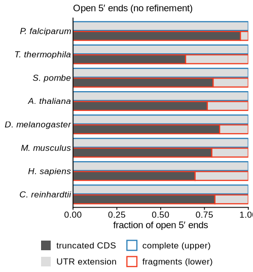

```r
org_rev <- rev(ORGS)
h <- 0.38
a_dat <- oe %>%
  mutate(i = match(org, org_rev) - 1,
         y = i + ifelse(input == "complete", h / 2 + 0.02, -h / 2 - 0.02)) %>%
  select(org, input, y, truncated, utr_extended) %>%
  mutate(n = truncated + utr_extended) %>%
  transmute(org, input, y, `truncated CDS` = truncated / n, `UTR extension` = utr_extended / n) %>%
  pivot_longer(c(`truncated CDS`, `UTR extension`), names_to = "class", values_to = "frac") %>%
  mutate(class = factor(class, levels = c("truncated CDS", "UTR extension"))) %>%
  arrange(org, input, class) %>% group_by(org, input) %>%
  mutate(xmax = cumsum(frac), xmin = xmax - frac) %>% ungroup()
p3a <- ggplot(a_dat) +
  geom_rect(aes(xmin = xmin, xmax = xmax, ymin = y - h / 2, ymax = y + h / 2, fill = class, colour = input),
            linewidth = 0.4) +
  scale_fill_manual(values = c(`truncated CDS` = "#555555", `UTR extension` = "#dddddd"), name = NULL) +
  scale_colour_manual(values = c(complete = COMPLETE_C, fragments = FRAG_C), name = NULL,
                      labels = c(complete = "complete (upper)", fragments = "fragments (lower)")) +
  scale_y_continuous(breaks = seq_along(org_rev) - 1, labels = ORG_LABEL[org_rev], expand = c(0.02, 0)) +
  scale_x_continuous(limits = c(0, 1), expand = c(0, 0)) +
  labs(x = "fraction of open 5′ ends", y = NULL, title = "Open 5′ ends (no refinement)") +
  guides(fill = guide_legend(ncol = 1, order = 1, override.aes = list(colour = NA)),
         colour = guide_legend(ncol = 1, order = 2, override.aes = list(fill = "white"))) +
  theme(axis.text.y = element_text(face = "italic"), axis.ticks.y = element_blank(),
        legend.position = "bottom", legend.box = "horizontal", legend.location = "plot",
        legend.margin = margin(0, 0, 0, 0))
p3a
```

**Fig. 3a values**

```r
kable(a_dat %>% select(org, input, class, frac) %>% mutate(frac = round(frac, 3)))
```

| org | input | class | frac |
| --- | --- | --- | --- |
| athal | complete | truncated CDS | 0.000 |
| athal | complete | UTR extension | 1.000 |
| athal | fragments | truncated CDS | 0.766 |
| athal | fragments | UTR extension | 0.234 |
| creinhardtii | complete | truncated CDS | 0.000 |
| creinhardtii | complete | UTR extension | 1.000 |
| creinhardtii | fragments | truncated CDS | 0.810 |
| creinhardtii | fragments | UTR extension | 0.190 |
| dmel | complete | truncated CDS | 0.000 |
| dmel | complete | UTR extension | 1.000 |
| dmel | fragments | truncated CDS | 0.836 |
| dmel | fragments | UTR extension | 0.164 |
| human | complete | truncated CDS | 0.000 |
| human | complete | UTR extension | 1.000 |
| human | fragments | truncated CDS | 0.696 |
| human | fragments | UTR extension | 0.304 |
| mouse | complete | truncated CDS | 0.000 |
| mouse | complete | UTR extension | 1.000 |
| mouse | fragments | truncated CDS | 0.792 |
| mouse | fragments | UTR extension | 0.208 |
| pfalciparum | complete | truncated CDS | 0.000 |
| pfalciparum | complete | UTR extension | 1.000 |
| pfalciparum | fragments | truncated CDS | 0.955 |
| pfalciparum | fragments | UTR extension | 0.045 |
| spombe | complete | truncated CDS | 0.000 |
| spombe | complete | UTR extension | 1.000 |
| spombe | fragments | truncated CDS | 0.800 |
| spombe | fragments | UTR extension | 0.200 |
| tthermophila | complete | truncated CDS | 0.000 |
| tthermophila | complete | UTR extension | 1.000 |
| tthermophila | fragments | truncated CDS | 0.642 |
| tthermophila | fragments | UTR extension | 0.358 |

E13

## Effect of refinement at the final code

Exact-CDS F1 of the grid’s default cell (α 0.4, w 25 per nat) against the run without refinement (`optima.tsv`, `norefine_f1`). Both come from the same code and have identical predicted stops.

```r
eff <- f1 %>% mutate(gain = pts(final - norefine))
ec <- eff %>% filter(input == "complete")
ef <- eff %>% filter(input == "fragments")
kable(eff %>% select(org, input, norefine, final, gain) %>% mutate(gain = round(gain, 2)),
      caption = "Exact F1 without refinement and at the default (grid), and the gain in points")
```

Exact F1 without refinement and at the default (grid), and the gain in points

| org | input | norefine | final | gain |
| --- | --- | --- | --- | --- |
| pfalciparum | complete | 0.8978 | 0.9284 | 3.06 |
| pfalciparum | fragments | 0.8484 | 0.8059 | -4.25 |
| tthermophila | complete | 0.4524 | 0.8398 | 38.74 |
| tthermophila | fragments | 0.6477 | 0.7620 | 11.43 |
| spombe | complete | 0.7182 | 0.9119 | 19.37 |
| spombe | fragments | 0.7762 | 0.7845 | 0.83 |
| athal | complete | 0.6816 | 0.8966 | 21.50 |
| athal | fragments | 0.7240 | 0.7226 | -0.14 |
| dmel | complete | 0.7541 | 0.9220 | 16.79 |
| dmel | fragments | 0.7854 | 0.7944 | 0.90 |
| mouse | complete | 0.7002 | 0.9082 | 20.80 |
| mouse | fragments | 0.7811 | 0.8019 | 2.08 |
| human | complete | 0.5633 | 0.9222 | 35.89 |
| human | fragments | 0.7257 | 0.8124 | 8.67 |
| creinhardtii | complete | 0.6135 | 0.7415 | 12.80 |
| creinhardtii | fragments | 0.7464 | 0.7605 | 1.41 |

```r
g <- function(d, o, col) d[[col]][d$org == o]
frag_pos <- sum(ef$gain > 0.05)
frag_neg <- sum(ef$gain < -0.05)
```

For reference, the release run (`pytd_v7`) has these exact F1 values on the same inputs; the release changes the stop set too (q-value test), so it is not a controlled comparison with no refinement:

```r
kable(f1 %>% select(org, input, grid_default = final, release, release_exact_sens = release_sens) %>%
        mutate(diff_points = round(pts(release - grid_default), 2)))
```

| org | input | grid_default | release | release_exact_sens | diff_points |
| --- | --- | --- | --- | --- | --- |
| pfalciparum | complete | 0.9284 | 0.9404 | 0.9381 | 1.20 |
| pfalciparum | fragments | 0.8059 | 0.8682 | 0.8417 | 6.23 |
| tthermophila | complete | 0.8398 | 0.8334 | 0.7944 | -0.64 |
| tthermophila | fragments | 0.7620 | 0.7594 | 0.6884 | -0.26 |
| spombe | complete | 0.9119 | 0.9163 | 0.9045 | 0.44 |
| spombe | fragments | 0.7845 | 0.8295 | 0.7843 | 4.50 |
| athal | complete | 0.8966 | 0.8992 | 0.8804 | 0.26 |
| athal | fragments | 0.7226 | 0.7531 | 0.6797 | 3.05 |
| dmel | complete | 0.9220 | 0.9279 | 0.9109 | 0.59 |
| dmel | fragments | 0.7944 | 0.8411 | 0.7900 | 4.67 |
| mouse | complete | 0.9082 | 0.9070 | 0.8951 | -0.12 |
| mouse | fragments | 0.8019 | 0.8180 | 0.7674 | 1.61 |
| human | complete | 0.9222 | 0.9199 | 0.9090 | -0.23 |
| human | fragments | 0.8124 | 0.8251 | 0.7797 | 1.27 |
| creinhardtii | complete | 0.7415 | 0.7469 | 0.7316 | 0.54 |
| creinhardtii | fragments | 0.7605 | 0.7783 | 0.7314 | 1.78 |

```r
check_text("results L21: complete gain min (pts)", round(min(ec$gain), 1), 3.1)
check_text("results L21: complete gain max (pts)", round(max(ec$gain), 1), 38.7)
check_text("results L21: complete gain median (pts)", round(median(ec$gain), 1), 20.1)
check_text("results L21: complete gain positive in all 8", sum(ec$gain > 0), 8)
check_text("results L22: T. thermophila no refinement", round(g(ec, "tthermophila", "norefine"), 3), 0.452)
check_text("results L22: T. thermophila default", round(g(ec, "tthermophila", "final"), 3), 0.840)
check_text("results L22: human no refinement", round(g(ec, "human", "norefine"), 3), 0.563)
check_text("results L22: human default", round(g(ec, "human", "final"), 3), 0.922)
check_text("results L23: fragments effect min (pts)", round(min(ef$gain), 1), -4.3)
check_text("results L23: fragments effect max (pts)", round(max(ef$gain), 1), 11.4)
check_text("results L23: fragments effect positive (n orgs)", frag_pos, 6)
check_text("results L24: A. thaliana fragments effect (pts)", round(g(ef, "athal", "gain"), 1), -0.1)
check_text("results L24: P. falciparum fragments no refinement", round(g(ef, "pfalciparum", "norefine"), 3), 0.848)
check_text("results L24: P. falciparum fragments default", round(g(ef, "pfalciparum", "final"), 3), 0.806)
check_text("results L25: P. falciparum has highest truncated share", as.numeric(oe_frag$org[which.max(oe_frag$trunc_frac)] == "pfalciparum"), 1)
```

E13

## The Kozak term protects truncated ORFs

Exact F1 at α 0.4 with $w=0$ and with the default weight (grid cells `a0.4_w0`, `a0.4_w25`).

```r
kz <- f1 %>% mutate(kozak_gain = pts(final - w0), w0_below_norefine = w0 < norefine)
kzc <- kz %>% filter(input == "complete")
kzf <- kz %>% filter(input == "fragments")
kable(kz %>% select(org, input, norefine, w0, final, kozak_gain, w0_below_norefine) %>%
        mutate(kozak_gain = round(kozak_gain, 2)))
```

| org | input | norefine | w0 | final | kozak_gain | w0_below_norefine |
| --- | --- | --- | --- | --- | --- | --- |
| pfalciparum | complete | 0.8978 | 0.9294 | 0.9284 | -0.10 | FALSE |
| pfalciparum | fragments | 0.8484 | 0.7910 | 0.8059 | 1.49 | TRUE |
| tthermophila | complete | 0.4524 | 0.8379 | 0.8398 | 0.19 | FALSE |
| tthermophila | fragments | 0.6477 | 0.7490 | 0.7620 | 1.30 | FALSE |
| spombe | complete | 0.7182 | 0.9121 | 0.9119 | -0.02 | FALSE |
| spombe | fragments | 0.7762 | 0.7647 | 0.7845 | 1.98 | TRUE |
| athal | complete | 0.6816 | 0.8875 | 0.8966 | 0.91 | FALSE |
| athal | fragments | 0.7240 | 0.6885 | 0.7226 | 3.41 | TRUE |
| dmel | complete | 0.7541 | 0.9136 | 0.9220 | 0.84 | FALSE |
| dmel | fragments | 0.7854 | 0.7663 | 0.7944 | 2.81 | TRUE |
| mouse | complete | 0.7002 | 0.9002 | 0.9082 | 0.80 | FALSE |
| mouse | fragments | 0.7811 | 0.7607 | 0.8019 | 4.12 | TRUE |
| human | complete | 0.5633 | 0.8937 | 0.9222 | 2.85 | FALSE |
| human | fragments | 0.7257 | 0.7691 | 0.8124 | 4.33 | FALSE |
| creinhardtii | complete | 0.6135 | 0.7465 | 0.7415 | -0.50 | FALSE |
| creinhardtii | fragments | 0.7464 | 0.7401 | 0.7605 | 2.04 | TRUE |

Without the Kozak term, refinement lowered fragment exact F1 below no refinement in 6 of 8 organisms. With it, exact F1 on fragments rose by 1.3 to 4.3 points compared with $w=0$ (positive in 8 of 8). On complete inputs the term changed exact F1 by -0.5 to 2.85 points (mean 0.6). The maximum, 2.85, is a difference of two F1 values rounded to 4 decimals; the text rounds it to 2.9.

### Self-trained and annotation-trained Kozak models (Supplementary Fig. S1)

The self-trained models are those of the release runs (`pytd_v7`, stranded `complete` input, `start_refinement.kozak.counts.tsv`); the annotation-trained models use annotated starts of transcripts with an annotated 5′ UTR against the in-frame ATGs inside those CDSs. Both are log2-odds with +1 pseudocounts (`kozak.py` of PyTD 3a793ff). The −3 A/G value is the log2-odds at −3 averaged over the A and G start sites (weighted by their counts), as in `make_kozak_figure.py`.

```r
kstat <- kmod %>%
  select(org, model, position, base, log2odds) %>%
  pivot_wider(names_from = model, values_from = log2odds) %>%
  group_by(org) %>% summarise(pearson_self_truth = cor(self, truth), .groups = "drop")
ag3 <- kmod %>% filter(position == "-3", base %in% c("A", "G")) %>%
  group_by(org, model) %>% summarise(v = sum(start_count * log2odds) / sum(start_count), .groups = "drop") %>%
  pivot_wider(names_from = model, values_from = v, names_prefix = "minus3_AG_")
g4 <- kmod %>% filter(position == "+4", base == "G") %>% select(org, model, log2odds) %>%
  pivot_wider(names_from = model, values_from = log2odds, names_prefix = "plus4_G_")
nst <- kmod %>% distinct(org, model, n_starts) %>% pivot_wider(names_from = model, values_from = n_starts,
                                                               names_prefix = "n_")
kstat <- nst %>% left_join(kstat, by = "org") %>% left_join(ag3, by = "org") %>% left_join(g4, by = "org") %>%
  mutate(org = factor(org, levels = ORGS)) %>% arrange(org)
kable(kstat, digits = 3, caption = "Kozak models: release self-trained vs annotation-trained")
```

Kozak models: release self-trained vs annotation-trained

| org | n_self | n_truth | pearson_self_truth | minus3_AG_self | minus3_AG_truth | plus4_G_self | plus4_G_truth |
| --- | --- | --- | --- | --- | --- | --- | --- |
| pfalciparum | 476 | 4406 | 0.958 | 0.392 | 0.597 | 0.437 | 0.464 |
| tthermophila | 253 | 26177 | 0.845 | 0.097 | 0.215 | -0.313 | 0.120 |
| spombe | 402 | 4501 | 0.883 | 0.412 | 0.700 | 0.169 | 0.116 |
| athal | 404 | 25725 | 0.908 | 0.193 | 0.353 | 0.884 | 0.707 |
| dmel | 465 | 13367 | 0.975 | 0.763 | 0.834 | 0.080 | 0.022 |
| mouse | 362 | 20575 | 0.964 | 0.531 | 0.520 | 0.479 | 0.549 |
| human | 325 | 18816 | 0.921 | 0.537 | 0.511 | 0.506 | 0.566 |
| creinhardtii | 395 | 17621 | 0.961 | 0.580 | 0.575 | 0.242 | 0.098 |

```r
cmp_old <- kstat %>% mutate(org = as.character(org)) %>%
  left_join(kstats_old %>% select(org, n_self_old = n_self_starts, n_truth_old = n_truth_starts,
                                  r_old = pearson_self_truth), by = "org") %>%
  select(org, n_self, n_self_old, n_truth, n_truth_old, pearson_self_truth, r_old)
kable(cmp_old, digits = 3, caption = "Against figures/kozak/kozak_stats.tsv (perl_td training sets, earlier figure)")
```

Against figures/kozak/kozak_stats.tsv (perl_td training sets, earlier figure)

| org | n_self | n_self_old | n_truth | n_truth_old | pearson_self_truth | r_old |
| --- | --- | --- | --- | --- | --- | --- |
| pfalciparum | 476 | 476 | 4406 | 4406 | 0.958 | 0.958 |
| tthermophila | 253 | 253 | 26177 | 26177 | 0.845 | 0.845 |
| spombe | 402 | 402 | 4501 | 4501 | 0.883 | 0.883 |
| athal | 404 | 404 | 25725 | 25725 | 0.908 | 0.908 |
| dmel | 465 | 465 | 13367 | 13367 | 0.975 | 0.975 |
| mouse | 362 | 362 | 20575 | 20575 | 0.964 | 0.964 |
| human | 325 | 325 | 18816 | 18816 | 0.921 | 0.921 |
| creinhardtii | 395 | 395 | 17621 | 17621 | 0.961 | 0.961 |

The release self-trained models have the same counts as the earlier `perl_td` training sets (table above), so the earlier statistics are unchanged. The lowest correlation, *T. thermophila*, is 0.8446, which is 0.84 to two decimals (the text’s 0.85 rounds the three-decimal 0.845). The release runs trained their Kozak models on 253–476 starts. Self-trained and annotation-trained log2-odds (8 positions × 4 bases) correlated with Pearson $r=$ 0.845–0.975. The −3 A/G log2-odds of the self-trained model was positive in 8 of 8 organisms (0.10 to 0.76).

```r
check_text("results L29: w=0 below no refinement on fragments (n orgs)", sum(kzf$w0_below_norefine), 6)
check_text("results L29: Kozak term fragments min (pts)", round(min(kzf$kozak_gain), 1), 1.3)
check_text("results L29: Kozak term fragments max (pts)", round(max(kzf$kozak_gain), 1), 4.3)
check_text("results L30: Kozak term fragments positive (n orgs)", sum(kzf$kozak_gain > 0), 8)
check_text("results L31: Kozak term complete min (pts)", round(min(kzc$kozak_gain), 1), -0.5)
check_text("results L31: Kozak term complete max (pts; 2.85 from 4-decimal F1s)", max(kzc$kozak_gain), 2.9, tol = 0.051)
check_text("results L31: Kozak term complete mean (pts)", round(mean(kzc$kozak_gain), 1), 0.6)
check_text("results L32: Pearson r min (T. thermophila 0.8446)", round(min(kstat$pearson_self_truth), 2), 0.84)
check_text("results L32: Pearson r max", round(max(kstat$pearson_self_truth), 2), 0.98)
check_text("results L33: -3 A/G preferred (n orgs)", sum(kstat$minus3_AG_self > 0), 8)
```

E13, E09

## One baseline for complete transcripts and fragments

Mean exact F1 over the eight organisms for each of the 78 cells (`plateau.tsv`). “both” is the per-organism mean of complete and fragments, averaged over organisms.

```r
pl <- plateau %>% mutate(w = weight)
both <- pl %>% filter(input == "both") %>% arrange(desc(mean_f1))
best_cell <- both$config[1]
frag_opt <- optima %>% filter(input == "fragments") %>% select(org, best_configs)
frag_opt_alpha <- frag_opt %>% separate_rows(best_configs, sep = ",") %>%
  mutate(alpha = as.numeric(sub("^a([0-9.]+)_w.*$", "\\1", best_configs)))
comp_opt_alpha <- optima %>% filter(input == "complete") %>% separate_rows(best_configs, sep = ",") %>%
  mutate(alpha = as.numeric(sub("^a([0-9.]+)_w.*$", "\\1", best_configs)))
loo_both <- loo %>% filter(scope == "both")
kable(both %>% head(10) %>% select(config, alpha, weight, mean_f1), digits = 4,
      caption = "Ten best cells, mean of complete and fragments")
```

Ten best cells, mean of complete and fragments

| config | alpha | weight | mean_f1 |
| --- | --- | --- | --- |
| a0.4_w25 | 0.4 | 25 | 0.8322 |
| a0.3_w25 | 0.3 | 25 | 0.8317 |
| a0.5_w25 | 0.5 | 25 | 0.8298 |
| a0.4_w10 | 0.4 | 10 | 0.8297 |
| a0.2_w25 | 0.2 | 25 | 0.8291 |
| a0.3_w10 | 0.3 | 10 | 0.8290 |
| a0.4_w50 | 0.4 | 50 | 0.8282 |
| a0.3_w50 | 0.3 | 50 | 0.8281 |
| a0.5_w10 | 0.5 | 10 | 0.8271 |
| a0.5_w50 | 0.5 | 50 | 0.8269 |

```r
kable(optima %>% select(org, input, best_configs, best_f1, default_f1, gap_f1_points), digits = 4,
      caption = "Best cell per organism and input")
```

Best cell per organism and input

| org | input | best_configs | best_f1 | default_f1 | gap_f1_points |
| --- | --- | --- | --- | --- | --- |
| athal | complete | a3_w0 | 0.9628 | 0.8966 | 6.62 |
| creinhardtii | complete | a3_w0 | 0.7800 | 0.7415 | 3.85 |
| dmel | complete | a3_w0,a3_w5 | 0.9444 | 0.9220 | 2.24 |
| human | complete | a3_w0,a3_w5 | 0.9679 | 0.9222 | 4.57 |
| mouse | complete | a3_w0 | 0.9388 | 0.9082 | 3.06 |
| pfalciparum | complete | a3_w0,a3_w5 | 0.9357 | 0.9284 | 0.73 |
| spombe | complete | a3_w0 | 0.9722 | 0.9119 | 6.03 |
| tthermophila | complete | a3_w0 | 0.9061 | 0.8398 | 6.63 |
| athal | fragments | a0_w25 | 0.7529 | 0.7226 | 3.03 |
| creinhardtii | fragments | a0.1_w10 | 0.7702 | 0.7605 | 0.97 |
| dmel | fragments | a0_w10 | 0.8127 | 0.7944 | 1.83 |
| human | fragments | a0.1_w25 | 0.8224 | 0.8124 | 1.00 |
| mouse | fragments | a0.1_w25 | 0.8162 | 0.8019 | 1.43 |
| pfalciparum | fragments | a0_w5 | 0.8367 | 0.8059 | 3.08 |
| spombe | fragments | a0_w25 | 0.8097 | 0.7845 | 2.52 |
| tthermophila | fragments | a0.2_w25 | 0.7667 | 0.7620 | 0.47 |

```r
kable(loo_both %>% select(held_out, chosen, heldout_f1_chosen, heldout_f1_default), digits = 4,
      caption = "Leave-one-organism-out selection (equal weights)")
```

Leave-one-organism-out selection (equal weights)

| held_out | chosen | heldout_f1_chosen | heldout_f1_default |
| --- | --- | --- | --- |
| athal | a0.4_w25 | 0.8096 | 0.8096 |
| creinhardtii | a0.4_w25 | 0.7510 | 0.7510 |
| dmel | a0.4_w25 | 0.8582 | 0.8582 |
| human | a0.4_w25 | 0.8673 | 0.8673 |
| mouse | a0.4_w25 | 0.8550 | 0.8550 |
| pfalciparum | a0.4_w25 | 0.8671 | 0.8671 |
| spombe | a0.4_w25 | 0.8482 | 0.8482 |
| tthermophila | a0.3_w25 | 0.7945 | 0.8009 |

78 cells were tested. With equal weights the best was a0.4_w25 (mean exact F1 0.8322). Per organism, the best cell on complete inputs was at α 3 in every organism, and on fragments at α 0–0.2. Leave-one-organism-out selection chose `a0.4_w25` in 7 of 8 folds (the *T. thermophila* fold chose a0.3_w25).

```r
check_text("results L39: fragments best alpha max", max(frag_opt_alpha$alpha), 0.2)
check_text("results L39: fragments best alpha min", min(frag_opt_alpha$alpha), 0)
check_text("results L40: default best of grid (1 = yes)", as.numeric(best_cell == "a0.4_w25"), 1)
check_text("results L40: number of parameter values", nrow(both), 78)
check_text("results L41: LOO folds choosing default", sum(loo_both$chosen == "a0.4_w25"), 7)
```

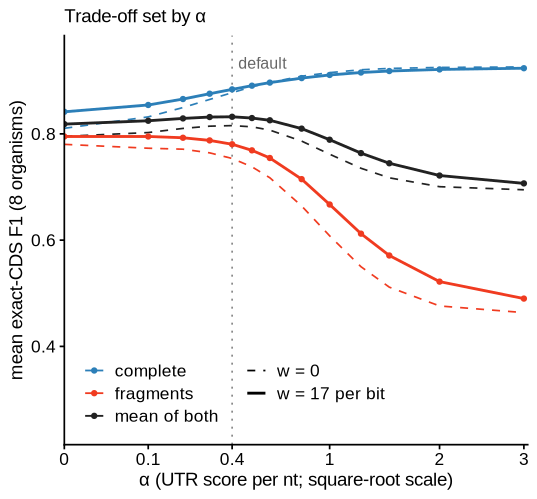

```r
c_dat <- pl %>% filter(weight %in% c(0, 25)) %>%
  mutate(input = factor(input, levels = c("complete", "fragments", "both")),
         wlab = ifelse(weight == 25, "w = 17 per bit", "w = 0"))
IN_COL <- c(complete = COMPLETE_C, fragments = FRAG_C, both = "#222222")
p3c <- ggplot(c_dat, aes(alpha, mean_f1, colour = input, group = interaction(input, wlab))) +
  geom_vline(xintercept = 0.4, colour = "#888888", linewidth = 0.3, linetype = "dotted") +
  geom_line(aes(linetype = wlab, linewidth = wlab)) +
  geom_point(data = c_dat %>% filter(weight == 25), size = 0.7) +
  annotate("text", x = 0.43, y = 0.945, label = "default", size = 2.1, colour = "#666666", hjust = 0, vjust = 1) +
  scale_x_sqrt(breaks = c(0, 0.1, 0.4, 1, 2, 3), labels = c("0", "0.1", "0.4", "1", "2", "3"),
               limits = c(0, 3.05), expand = c(0, 0)) +
  scale_y_continuous(limits = c(0.25, 0.95)) +
  scale_colour_manual(values = IN_COL, labels = c(complete = "complete", fragments = "fragments",
                                                  both = "mean of both"), name = NULL) +
  scale_linetype_manual(values = c(`w = 17 per bit` = "solid", `w = 0` = "dashed"), name = NULL) +
  scale_linewidth_manual(values = c(`w = 17 per bit` = 0.5, `w = 0` = 0.3), name = NULL) +
  labs(x = "α (UTR score per nt; square-root scale)", y = "mean exact-CDS F1 (8 organisms)",
       title = "Trade-off set by α") +
  guides(colour = guide_legend(order = 1), linetype = guide_legend(order = 2), linewidth = guide_legend(order = 2)) +
  theme(legend.position = c(0.02, 0.02), legend.justification = c(0, 0), legend.box = "horizontal",
        legend.spacing.x = unit(1, "mm"))
p3c
```

**Fig. 3c values**

```r
kable(c_dat %>% select(input, weight_per_nat = weight, alpha, mean_f1) %>% arrange(input, weight_per_nat, alpha),
      digits = 4)
```

| input | weight_per_nat | alpha | mean_f1 |
| --- | --- | --- | --- |
| complete | 0 | 0.00 | 0.8105 |
| complete | 0 | 0.10 | 0.8320 |
| complete | 0 | 0.20 | 0.8496 |
| complete | 0 | 0.30 | 0.8648 |
| complete | 0 | 0.40 | 0.8776 |
| complete | 0 | 0.50 | 0.8886 |
| complete | 0 | 0.60 | 0.8969 |
| complete | 0 | 0.80 | 0.9086 |
| complete | 0 | 1.00 | 0.9153 |
| complete | 0 | 1.25 | 0.9207 |
| complete | 0 | 1.50 | 0.9232 |
| complete | 0 | 2.00 | 0.9251 |
| complete | 0 | 3.00 | 0.9260 |
| complete | 25 | 0.00 | 0.8416 |
| complete | 25 | 0.10 | 0.8544 |
| complete | 25 | 0.20 | 0.8656 |
| complete | 25 | 0.30 | 0.8756 |
| complete | 25 | 0.40 | 0.8838 |
| complete | 25 | 0.50 | 0.8907 |
| complete | 25 | 0.60 | 0.8965 |
| complete | 25 | 0.80 | 0.9050 |
| complete | 25 | 1.00 | 0.9109 |
| complete | 25 | 1.25 | 0.9155 |
| complete | 25 | 1.50 | 0.9183 |
| complete | 25 | 2.00 | 0.9213 |
| complete | 25 | 3.00 | 0.9236 |
| fragments | 0 | 0.00 | 0.7803 |
| fragments | 0 | 0.10 | 0.7730 |
| fragments | 0 | 0.20 | 0.7712 |
| fragments | 0 | 0.30 | 0.7643 |
| fragments | 0 | 0.40 | 0.7537 |
| fragments | 0 | 0.50 | 0.7380 |
| fragments | 0 | 0.60 | 0.7174 |
| fragments | 0 | 0.80 | 0.6643 |
| fragments | 0 | 1.00 | 0.6081 |
| fragments | 0 | 1.25 | 0.5500 |
| fragments | 0 | 1.50 | 0.5115 |
| fragments | 0 | 2.00 | 0.4761 |
| fragments | 0 | 3.00 | 0.4636 |
| fragments | 25 | 0.00 | 0.7951 |
| fragments | 25 | 0.10 | 0.7951 |
| fragments | 25 | 0.20 | 0.7927 |
| fragments | 25 | 0.30 | 0.7877 |
| fragments | 25 | 0.40 | 0.7805 |
| fragments | 25 | 0.50 | 0.7690 |
| fragments | 25 | 0.60 | 0.7546 |
| fragments | 25 | 0.80 | 0.7148 |
| fragments | 25 | 1.00 | 0.6671 |
| fragments | 25 | 1.25 | 0.6122 |
| fragments | 25 | 1.50 | 0.5711 |
| fragments | 25 | 2.00 | 0.5219 |
| fragments | 25 | 3.00 | 0.4900 |
| both | 0 | 0.00 | 0.7954 |
| both | 0 | 0.10 | 0.8025 |
| both | 0 | 0.20 | 0.8103 |
| both | 0 | 0.30 | 0.8145 |
| both | 0 | 0.40 | 0.8156 |
| both | 0 | 0.50 | 0.8133 |
| both | 0 | 0.60 | 0.8071 |
| both | 0 | 0.80 | 0.7864 |
| both | 0 | 1.00 | 0.7617 |
| both | 0 | 1.25 | 0.7353 |
| both | 0 | 1.50 | 0.7173 |
| both | 0 | 2.00 | 0.7006 |
| both | 0 | 3.00 | 0.6948 |
| both | 25 | 0.00 | 0.8184 |
| both | 25 | 0.10 | 0.8247 |
| both | 25 | 0.20 | 0.8291 |
| both | 25 | 0.30 | 0.8317 |
| both | 25 | 0.40 | 0.8322 |
| both | 25 | 0.50 | 0.8298 |
| both | 25 | 0.60 | 0.8256 |
| both | 25 | 0.80 | 0.8099 |
| both | 25 | 1.00 | 0.7890 |
| both | 25 | 1.25 | 0.7638 |
| both | 25 | 1.50 | 0.7447 |
| both | 25 | 2.00 | 0.7216 |
| both | 25 | 3.00 | 0.7068 |

E13

## Comparison with earlier releases

v6.0.0 (`perl_td_v600`, `summary.tsv`) against the release (`pytd_v7`, `all_scores.tsv`), the values the manuscript quotes. The development default (`pytd_dev_v2`, equal to the grid’s default cell), from which an earlier draft was written, is shown alongside. The fixed PWM is `pytd` in `summary.tsv` (PyTD 27bfb5e).

```r
rel <- f1 %>% mutate(gain_release = pts(release - v600), gain_dev = pts(final - v600),
                     stop_release = pts(release_stop - v600_stop), stop_dev = pts(final_stop - v600_stop))
rc <- rel %>% filter(input == "complete")
rf <- rel %>% filter(input == "fragments")
fixed_pwm <- summ %>% filter(tool == "pytd", variant == "complete")
kable(rel %>% select(org, input, v600, dev_default = final, release, gain_dev, gain_release,
                     stop_dev, stop_release) %>%
        mutate(across(starts_with(c("gain", "stop")), ~ round(.x, 2))), digits = 4,
      caption = "Exact F1 and gains (points) over v6.0.0; stop_* are stop-level F1 changes")
```

Exact F1 and gains (points) over v6.0.0; stop_* are stop-level F1 changes

| org | input | v600 | dev_default | release | gain_dev | gain_release | stop_dev | stop_release |
| --- | --- | --- | --- | --- | --- | --- | --- | --- |
| pfalciparum | complete | 0.9119 | 0.9284 | 0.9404 | 1.65 | 2.85 | 0.12 | 1.33 |
| pfalciparum | fragments | 0.7882 | 0.8059 | 0.8682 | 1.77 | 8.00 | 1.71 | 8.76 |
| tthermophila | complete | 0.5673 | 0.8398 | 0.8334 | 27.25 | 26.61 | -0.74 | -1.43 |
| tthermophila | fragments | 0.6215 | 0.7620 | 0.7594 | 14.05 | 13.79 | 2.01 | 1.15 |
| spombe | complete | 0.7806 | 0.9119 | 0.9163 | 13.13 | 13.57 | 0.80 | 1.31 |
| spombe | fragments | 0.7146 | 0.7845 | 0.8295 | 6.99 | 11.49 | 4.95 | 10.10 |
| athal | complete | 0.7768 | 0.8966 | 0.8992 | 11.98 | 12.24 | 0.35 | 0.66 |
| athal | fragments | 0.6928 | 0.7226 | 0.7531 | 2.98 | 6.03 | 3.12 | 6.59 |
| dmel | complete | 0.8109 | 0.9220 | 0.9279 | 11.11 | 11.70 | 0.62 | 1.23 |
| dmel | fragments | 0.7298 | 0.7944 | 0.8411 | 6.46 | 11.13 | 4.91 | 10.14 |
| mouse | complete | 0.7938 | 0.9082 | 0.9070 | 11.44 | 11.32 | 0.38 | 0.27 |
| mouse | fragments | 0.7398 | 0.8019 | 0.8180 | 6.21 | 7.82 | 4.03 | 5.73 |
| human | complete | 0.7546 | 0.9222 | 0.9199 | 16.76 | 16.53 | 0.37 | 0.12 |
| human | fragments | 0.7158 | 0.8124 | 0.8251 | 9.66 | 10.93 | 3.81 | 5.21 |
| creinhardtii | complete | 0.6697 | 0.7415 | 0.7469 | 7.18 | 7.72 | 0.60 | 1.21 |
| creinhardtii | fragments | 0.7057 | 0.7605 | 0.7783 | 5.48 | 7.26 | 4.12 | 6.28 |

```r
tp_tab <- tibble(run = c("v6.0.0", "development default", "release (pytd_v7)"),
                 median_exact_f1_complete = c(median(rc$v600), median(rc$final), median(rc$release)),
                 summed_exact_complete = c(sum(rc$v600_tp), sum(rc$final_tp), sum(rc$release_tp)))
kable(tp_tab, digits = 3, format.args = list(big.mark = ","))
```

| run | median_exact_f1_complete | summed_exact_complete |
| --- | --- | --- |
| v6.0.0 | 0.779 | 96,957 |
| development default | 0.910 | 116,384 |
| release (pytd_v7) | 0.912 | 116,362 |

On complete inputs, median exact F1 was 0.779 with v6.0.0 and 0.912 with the release (0.910 with the development default). Summed exact matches were 96,957 with v6.0.0 and 116,362 with the release (116,384, development). The release gained 2.8 to 26.6 points of exact F1 per organism, while stop-level F1 changed by -1.4 to 1.3 points. On fragments the release gained 6.0 to 13.8 points of exact F1 and 1.1 to 10.1 points of stop-level F1 (development default: 1.8 to 14.0 and 1.7 to 4.9). The fixed PWM had a median exact F1 of 0.728 on complete inputs.

The development values agree with the earlier draft: complete gain 1.65 to 27.25 (text 1.7 to 27.3; half-values rounded up), stop-level -0.7 to 0.8, fragments 1.77 to 14.05.

### PWM seeds (v6.0.0-style refinement)

```r
kable(seeds)
```

| dataset | seed | n_orfs | n_orfs_seed1 | same_stop_diff_start | stop_not_shared |
| --- | --- | --- | --- | --- | --- |
| pasa | 2 | 792 | 792 | 53 | 0 |
| pasa | 3 | 792 | 792 | 30 | 0 |
| pasa | 4 | 792 | 792 | 61 | 0 |
| pasa | 5 | 792 | 792 | 29 | 0 |
| stringtie | 2 | 3037 | 3037 | 144 | 0 |
| stringtie | 3 | 3037 | 3037 | 47 | 0 |
| stringtie | 4 | 3037 | 3037 | 111 | 0 |
| stringtie | 5 | 3037 | 3037 | 54 | 0 |

```r
sp <- seeds %>% filter(dataset == "pasa")
ss <- seeds %>% filter(dataset == "stringtie")
stopifnot(all(seeds$stop_not_shared == 0), all(seeds$n_orfs == seeds$n_orfs_seed1))
```

On the PASA sample data (792 ORFs), seeds 2–5 changed 29–61 start codons relative to seed 1; on the StringTie sample data (3,037 ORFs), 47–144. All stops were shared.

```r
check_text("results L44: v6.0.0 median exact F1 complete", round(median(rc$v600), 3), 0.779)
check_text("results L44: final median exact F1 complete (release)", round(median(rc$release), 3), 0.912)
check_text("results L45: v6.0.0 summed exact matches", sum(rc$v600_tp), 96957)
check_text("results L45: final summed exact matches (release)", sum(rc$release_tp), 116362)
check_text("results L45: gain per organism min (release, pts)", round(min(rc$gain_release), 1), 2.8)
check_text("results L45: gain per organism max (release, pts)", round(max(rc$gain_release), 1), 26.6)
check_text("results L46: stop F1 change min (release, pts)", round(min(rc$stop_release), 1), -1.4)
check_text("results L46: stop F1 change max (release, pts)", round(max(rc$stop_release), 1), 1.3)
check_text("results L46: fragments exact gain min (release, pts)", round(min(rf$gain_release), 1), 6.0)
check_text("results L46: fragments exact gain max (release, pts)", round(max(rf$gain_release), 1), 13.8)
check_text("results L48: fragments stop F1 gain min (release, pts)", round(min(rf$stop_release), 1), 1.1)
check_text("results L48: fragments stop F1 gain max (release, pts)", round(max(rf$stop_release), 1), 10.1)
check_text("results L49: fixed PWM median exact F1 complete", round(median(fixed_pwm$f1_exact), 3), 0.728)
check_text("results L51: PASA ORFs", sp$n_orfs[1], 792)
check_text("results L51: StringTie ORFs", ss$n_orfs[1], 3037)
check_text("results L51: PASA seeds min changed", min(sp$same_stop_diff_start), 29)
check_text("results L51: PASA seeds max changed", max(sp$same_stop_diff_start), 61)
check_text("results L52: StringTie seeds min changed", min(ss$same_stop_diff_start), 47)
check_text("results L52: StringTie seeds max changed", max(ss$same_stop_diff_start), 144)
```

E07, E09, E25

## Remaining start errors

Exact F1 on complete inputs (release) and the position of the annotated start among in-frame ATGs. “Later” means an in-frame ATG lies upstream of the annotated start with no stop in between; the set is + strand transcripts with an annotated 5′ UTR, an ATG start and a full 31-nt window (the definition of `pwm_audit/audit_signal.py` Q4).

```r
rem <- rel %>% filter(input == "complete") %>% select(org, dev_default = final, release) %>%
  left_join(later %>% mutate(later_frac = (closed_later + open_later) / n), by = "org")
kable(rem, digits = 4)
```

| org | dev_default | release | n | closed_first | closed_later | open_first | open_later | later_frac |
| --- | --- | --- | --- | --- | --- | --- | --- | --- |
| pfalciparum | 0.9284 | 0.9404 | 4338 | 4004 | 203 | 117 | 14 | 0.0500 |
| tthermophila | 0.8398 | 0.8334 | 25495 | 13064 | 261 | 11536 | 634 | 0.0351 |
| spombe | 0.9119 | 0.9163 | 4094 | 3265 | 29 | 797 | 3 | 0.0078 |
| athal | 0.8966 | 0.8992 | 24205 | 17888 | 121 | 6146 | 50 | 0.0071 |
| dmel | 0.9220 | 0.9279 | 12753 | 10241 | 231 | 2178 | 103 | 0.0262 |
| mouse | 0.9082 | 0.9070 | 20332 | 14560 | 540 | 4878 | 354 | 0.0440 |
| human | 0.9222 | 0.9199 | 18081 | 10677 | 160 | 7058 | 186 | 0.0191 |
| creinhardtii | 0.7415 | 0.7469 | 17536 | 11098 | 2097 | 3001 | 1340 | 0.1960 |

```r
cre <- rem %>% filter(org == "creinhardtii")
oth <- rem %>% filter(org != "creinhardtii")
```

*C. reinhardtii* had the lowest exact F1 on complete inputs in the release (0.747; development default 0.742; lowest: creinhardtii). Its annotated start was a later in-frame ATG in 19.6% of transcripts, against 0.7%–5.0% in the other seven.

```r
check_text("results L56: C. reinhardtii lowest exact F1 complete (1 = yes)", as.numeric(rem$org[which.min(rem$release)] == "creinhardtii"), 1)
check_text("results L56: C. reinhardtii exact F1 complete (release)", round(cre$release, 3), 0.747)
check_text("results L57: C. reinhardtii later ATG (%)", round(100 * cre$later_frac, 1), 19.6)
check_text("results L58: other organisms later ATG min (%)", round(100 * min(oth$later_frac), 1), 0.7)
check_text("results L58: other organisms later ATG max (%)", round(100 * max(oth$later_frac), 1), 5.0)
```

E09, E25

## Truncated ORFs and short UTRs are hard to tell apart

Release runs (`pytd_v7`) on the stranded complete, complete_fullutr and fragment inputs and on the balanced mixed inputs (E28), with each selected ORF’s keep-or-trim decision re-derived from `best_candidates.gff3` (it agrees with `revised_starts.gff3` in all 51 runs); GM12878 release runs with transcript-level truth from MANE; the reference annotations; and fresh runs of the unmerged UTR-length prior prototype (PyTD branch `exp/utr-prior`, c9d7875, λ = 1). Scripts `pipeline/derive/03_utr_*.py`, tables in `data/start_refinement/utr_prior/`. *d* is the 5′ UTR implied by trimming an open ORF to its first in-frame ATG.

```r
UP <- function(f) read_tab("start_refinement", "utr_prior", f)
anat <- UP("release.anatomy.tsv")
dbd <- UP("release.decision_by_d.tsv")
dbd_gm <- UP("release_gm12878.decision_by_d.tsv")
ann_utr <- UP("annotation_utr5_summary.tsv")
trunc_d <- UP("trunc_d_summary.tsv")
gm_trunc <- UP("gm12878_five_prime_truncation.tsv")
prior_bench <- UP("utr_prior_eval.bench.tsv")
prior_gm <- UP("utr_prior_eval.gm12878.tsv")
DBINS <- c("0-9", "10-19", "20-49", "50-99", "100-199", "200-499", ">=500")
input_set <- function(i) ifelse(grepl("^fragments_mixed", i), "mixed", i)
```

### Error anatomy

5′ partials on the stranded fragments: every prediction with the correct stop but not the exact start should be a trim to an internal in-frame ATG (`trim_trunc`). Start-present references (complete transcripts and the 3′ partials of the fragment inputs): share of predictions with the correct stop that were left open through the true start into the UTR (`open_utr`).

```r
f5 <- anat %>% filter(input == "fragments", ref_type == "5prime_partial") %>%
  mutate(stop_sens = n_stop / n_ref, exact_sens = exact / n_ref, wrong_start = n_stop - exact,
         other_errors = open_utr + trim_upstream + atg_other + other)
kable(f5 %>% select(org, n_ref, stop_sens, exact_sens, wrong_start, trim_trunc, other_errors,
                    median_d = trim_trunc_median_d, d_lt20 = trim_trunc_frac_d_lt20,
                    d_lt50 = trim_trunc_frac_d_lt50, trimmed_cds = trim_trunc_median_trimmed_frac),
      digits = 3, caption = "5' partials, stranded fragments (release)")
```

5’ partials, stranded fragments (release)

| org | n_ref | stop_sens | exact_sens | wrong_start | trim_trunc | other_errors | median_d | d_lt20 | d_lt50 | trimmed_cds |
| --- | --- | --- | --- | --- | --- | --- | --- | --- | --- | --- |
| human | 9483 | 0.874 | 0.723 | 1437 | 1437 | 0 | 59 | 0.188 | 0.438 | 0.093 |
| mouse | 10572 | 0.867 | 0.726 | 1496 | 1496 | 0 | 60 | 0.193 | 0.438 | 0.094 |
| dmel | 6878 | 0.869 | 0.748 | 834 | 834 | 0 | 48 | 0.239 | 0.516 | 0.073 |
| athal | 13326 | 0.799 | 0.616 | 2434 | 2434 | 0 | 63 | 0.180 | 0.422 | 0.114 |
| spombe | 2528 | 0.892 | 0.744 | 375 | 375 | 0 | 46 | 0.219 | 0.512 | 0.088 |
| tthermophila | 13125 | 0.798 | 0.663 | 1774 | 1774 | 0 | 56 | 0.180 | 0.449 | 0.063 |
| pfalciparum | 2609 | 0.932 | 0.806 | 330 | 330 | 0 | 55 | 0.221 | 0.461 | 0.085 |
| creinhardtii | 8729 | 0.893 | 0.811 | 717 | 717 | 0 | 54 | 0.247 | 0.480 | 0.059 |

```r
spres <- anat %>% filter(input %in% c("complete", "complete_fullutr", "fragments"),
                      ref_type %in% c("complete", "3prime_partial")) %>%
  mutate(open_frac = open_utr / n_stop)
sp_org <- spres %>% group_by(org) %>% summarise(open_frac = sum(open_utr) / sum(n_stop), .groups = "drop")
kable(spres %>% select(org, input, ref_type, n_stop, open_utr, open_frac, true_utr_median = open_utr_median_true_utr) %>%
        pivot_wider(id_cols = org, names_from = c(input, ref_type), values_from = open_frac),
      digits = 4, caption = "Start-present references left open (share of correct-stop predictions)")
```

Start-present references left open (share of correct-stop predictions)

| org | complete_complete | complete_fullutr_complete | fragments_3prime_partial |
| --- | --- | --- | --- |
| human | 0.0507 | 0.0499 | 0.0560 |
| mouse | 0.0381 | 0.0360 | 0.0365 |
| dmel | 0.0258 | 0.0232 | 0.0276 |
| athal | 0.0699 | 0.0680 | 0.0683 |
| spombe | 0.0618 | 0.0606 | 0.0618 |
| tthermophila | 0.0777 | 0.0695 | 0.0853 |
| pfalciparum | 0.0086 | 0.0075 | 0.0092 |
| creinhardtii | 0.0596 | 0.0414 | 0.0627 |

```r
sp_type <- spres %>% group_by(input, ref_type) %>% summarise(median = median(open_frac), .groups = "drop")
kable(sp_type, digits = 4, caption = "Median over organisms per input type")
```

Median over organisms per input type

| input | ref_type | median |
| --- | --- | --- |
| complete | complete | 0.0551 |
| complete_fullutr | complete | 0.0457 |
| fragments | 3prime_partial | 0.0589 |

On the stranded fragments, 9,397 5′ partials had the correct stop but not the exact start; 9,397 of them were trims to an internal ATG and 0 were other errors. Median over organisms: stop found 0.871, exact 0.735. The trims lay a median 46–63 nt from the fragment start. Start-present references were left open through the true start in 0.7%–8.5% of correct-stop predictions (organism × input type); the median over organisms of the per-organism rates is 5.2% (per input type 5.5%, 4.6%, 5.9%), which the text gives as “about 5%”.

```r
check_text("results L73: 5' partials, correct stop but wrong start (n)", sum(f5$wrong_start), 9397)
check_text("results L74: all of them trimmed to an internal ATG (1 = yes)",
           as.numeric(sum(f5$trim_trunc) == sum(f5$wrong_start) && sum(f5$other_errors) == 0), 1)
check_text("results L75: start-present left open, median over organisms (about 5%)",
           round(100 * median(sp_org$open_frac)), 5)
check_text("results L75: start-present left open, min (%)", round(100 * min(spres$open_frac), 1), 0.7)
check_text("results L75: start-present left open, max (%)", round(100 * max(spres$open_frac), 1), 8.5)
```

### Decisions by distance to the first ATG

Complete and fragment inputs (the complete_fullutr and mixed inputs are not included), all organisms pooled. “Truncated”: 5′-partial reference, keeping the ORF open is right; share trimmed. “UTR, first ATG”: start-present reference whose start is the first in-frame ATG, trimming is right; share left open.

```r
byd <- dbd %>% filter(input %in% c("complete", "fragments"), dclass %in% c("truncated", "utr_first")) %>%
  group_by(dclass, dbin) %>% summarise(n = sum(n), n_trim = sum(n_trim), .groups = "drop") %>%
  mutate(error = ifelse(dclass == "truncated", n_trim / n, 1 - n_trim / n),
         dbin = factor(dbin, DBINS)) %>% arrange(dclass, dbin)
kable(byd, digits = 3, caption = "Error rate by d (truncated: trimmed; UTR, first ATG: left open)")
```

Error rate by d (truncated: trimmed; UTR, first ATG: left open)

| dclass | dbin | n | n_trim | error |
| --- | --- | --- | --- | --- |
| truncated | 0-9 | 2629 | 799 | 0.304 |
| truncated | 10-19 | 3517 | 1049 | 0.298 |
| truncated | 20-49 | 8997 | 2378 | 0.264 |
| truncated | 50-99 | 11222 | 2241 | 0.200 |
| truncated | 100-199 | 13156 | 1792 | 0.136 |
| truncated | 200-499 | 10679 | 1012 | 0.095 |
| truncated | >=500 | 1797 | 126 | 0.070 |
| utr_first | 0-9 | 1409 | 903 | 0.359 |
| utr_first | 10-19 | 3838 | 2957 | 0.230 |
| utr_first | 20-49 | 13517 | 11077 | 0.181 |
| utr_first | 50-99 | 16945 | 14433 | 0.148 |
| utr_first | 100-199 | 12845 | 11357 | 0.116 |
| utr_first | 200-499 | 7259 | 5973 | 0.177 |

```r
tr_lt20 <- byd %>% filter(dclass == "truncated", dbin %in% c("0-9", "10-19")) %>%
  summarise(e = sum(n_trim) / sum(n)) %>% pull(e)
err <- function(cl, b) byd$error[byd$dclass == cl & byd$dbin == b]
gm_byd <- dbd_gm %>% filter(dclass == "truncated") %>%
  mutate(d20 = ifelse(dbin %in% c("0-9", "10-19"), "d < 20", "d >= 20")) %>%
  group_by(assembly = input, d20) %>% summarise(n = sum(n), trimmed = sum(n_trim) / sum(n), .groups = "drop")
kable(gm_byd, digits = 3, caption = "GM12878 (release runs): truncated ORFs trimmed, by d")
```

GM12878 (release runs): truncated ORFs trimmed, by d

| assembly | d20 | n | trimmed |
| --- | --- | --- | --- |
| lraa | d < 20 | 161 | 0.453 |
| lraa | d >= 20 | 989 | 0.245 |
| stringtie | d < 20 | 59 | 0.475 |
| stringtie | d >= 20 | 674 | 0.175 |
| trinity | d < 20 | 124 | 0.347 |
| trinity | d >= 20 | 973 | 0.210 |

```r
gm_lt20 <- gm_byd %>% filter(d20 == "d < 20")
```

Truncated ORFs were trimmed in 30% of cases at d < 20 nt and 7% at d ≥ 500; UTR extensions were left open in 36% at d < 10 and 12% at 100–199 nt. On GM12878 the same dependence holds: truncated ORFs at d < 20 were trimmed in 35%–47% (more than at d ≥ 20 in every assembly).

```r
check_text("results L78: truncated trimmed, d < 20 (%)", round(100 * tr_lt20), 30)
check_text("results L79: truncated trimmed, d >= 500 (%)", round(100 * err("truncated", ">=500")), 7)
check_text("results L79: UTR extensions left open, d < 10 (%)", round(100 * err("utr_first", "0-9")), 36)
check_text("results L80: UTR extensions left open, d 100-199 (%)", round(100 * err("utr_first", "100-199")), 12)
check_text("results L85: GM12878 truncated trimmed more at d < 20 than at d >= 20 in all three (1 = yes)",
           as.numeric(all(gm_byd %>% group_by(assembly) %>%
                            summarise(x = trimmed[d20 == "d < 20"] > trimmed[d20 == "d >= 20"]) %>% pull(x))), 1)
```

### Cut model and annotated UTRs

Distance from a cut inside an annotated CDS to the next in-frame ATG, for uniform and N(0.5, 0.1) cut positions (`trunc_d_summary.tsv`; `no_atg` = no in-frame ATG downstream of the cut; the other fractions are among cuts with an ATG), and 5′ UTR lengths of all eligible annotated transcripts (`annotation_utr5_summary.tsv`; “open” = no in-frame stop upstream of the start, the UTRs that leave an ORF open on a complete transcript).

```r
cut_cmp <- trunc_d %>% pivot_wider(id_cols = org, names_from = cut, values_from = c(lt10, lt20, lt50, median_d, no_atg))
kable(cut_cmp, digits = 3)
```

| org | lt10_uniform | lt10_normal | lt20_uniform | lt20_normal | lt50_uniform | lt50_normal | median_d_uniform | median_d_normal | no_atg_uniform | no_atg_normal |
| --- | --- | --- | --- | --- | --- | --- | --- | --- | --- | --- |
| human | 0.057 | 0.059 | 0.110 | 0.114 | 0.260 | 0.272 | 100.177 | 102.926 | 0.101 | 0.037 |
| mouse | 0.060 | 0.062 | 0.114 | 0.119 | 0.269 | 0.281 | 96.702 | 99.650 | 0.099 | 0.034 |
| dmel | 0.063 | 0.065 | 0.120 | 0.125 | 0.280 | 0.293 | 91.158 | 92.978 | 0.105 | 0.045 |
| athal | 0.064 | 0.067 | 0.123 | 0.128 | 0.288 | 0.304 | 86.625 | 88.050 | 0.112 | 0.038 |
| spombe | 0.054 | 0.057 | 0.105 | 0.111 | 0.250 | 0.266 | 101.579 | 102.781 | 0.116 | 0.043 |
| tthermophila | 0.048 | 0.048 | 0.092 | 0.092 | 0.223 | 0.224 | 119.302 | 128.514 | 0.102 | 0.040 |
| pfalciparum | 0.061 | 0.063 | 0.116 | 0.120 | 0.270 | 0.280 | 101.861 | 102.697 | 0.063 | 0.017 |
| creinhardtii | 0.049 | 0.050 | 0.093 | 0.097 | 0.221 | 0.230 | 126.939 | 129.478 | 0.084 | 0.028 |

```r
cut_diff <- cut_cmp %>% transmute(org, d_lt10 = lt10_normal - lt10_uniform, d_lt20 = lt20_normal - lt20_uniform,
                                  d_lt50 = lt50_normal - lt50_uniform,
                                  median_ratio = median_d_normal / median_d_uniform)
kable(cut_diff, digits = 4, caption = "normal minus uniform")
```

normal minus uniform

| org | d_lt10 | d_lt20 | d_lt50 | median_ratio |
| --- | --- | --- | --- | --- |
| human | 0.0022 | 0.0044 | 0.0115 | 1.0274 |
| mouse | 0.0025 | 0.0050 | 0.0123 | 1.0305 |
| dmel | 0.0024 | 0.0050 | 0.0132 | 1.0200 |
| athal | 0.0022 | 0.0049 | 0.0163 | 1.0164 |
| spombe | 0.0029 | 0.0059 | 0.0164 | 1.0118 |
| tthermophila | 0.0000 | 0.0001 | 0.0014 | 1.0772 |
| pfalciparum | 0.0022 | 0.0043 | 0.0101 | 1.0082 |
| creinhardtii | 0.0016 | 0.0033 | 0.0091 | 1.0200 |

```r
open_utr <- ann_utr %>% filter(set == "all", utr_kind == "open")
kable(ann_utr %>% filter(set == "all", utr_kind %in% c("any", "open")) %>%
        select(org, utr_kind, n, frac_of_tx, median, lt10, lt20, lt50), digits = 3)
```

| org | utr_kind | n | frac_of_tx | median | lt10 | lt20 | lt50 |
| --- | --- | --- | --- | --- | --- | --- | --- |
| human | any | 18890 | 0.982 | 136 | 0.007 | 0.039 | 0.165 |
| human | open | 7634 | 0.397 | 70 | 0.017 | 0.092 | 0.352 |
| mouse | any | 163386 | 0.983 | 271 | 0.002 | 0.005 | 0.036 |
| mouse | open | 30308 | 0.182 | 118 | 0.010 | 0.024 | 0.147 |
| dmel | any | 29537 | 0.981 | 189 | 0.008 | 0.028 | 0.112 |
| dmel | open | 4588 | 0.152 | 53 | 0.051 | 0.164 | 0.476 |
| athal | any | 35382 | 0.968 | 111 | 0.014 | 0.051 | 0.198 |
| athal | open | 9068 | 0.248 | 48 | 0.052 | 0.170 | 0.512 |
| spombe | any | 4511 | 0.883 | 97 | 0.016 | 0.090 | 0.297 |
| spombe | open | 1178 | 0.230 | 27 | 0.061 | 0.320 | 0.811 |
| tthermophila | any | 26177 | 0.990 | 149 | 0.011 | 0.026 | 0.111 |
| tthermophila | open | 12201 | 0.461 | 95 | 0.022 | 0.052 | 0.204 |
| pfalciparum | any | 4421 | 0.826 | 497 | 0.004 | 0.015 | 0.048 |
| pfalciparum | open | 172 | 0.032 | 32 | 0.081 | 0.320 | 0.674 |
| creinhardtii | any | 19387 | 1.000 | 191 | 0.002 | 0.004 | 0.081 |
| creinhardtii | open | 4001 | 0.206 | 93 | 0.009 | 0.020 | 0.263 |

Uniform and normal cuts give d distributions within 0.006 (fractions below 10 and 20 nt) and 0.016 (below 50 nt), with medians within 8%. (The share of cuts with no downstream in-frame ATG differs, 6%–12% uniform against 2%–5% normal, because uniform cuts fall more often near the 3′ end; those ORFs have no trim option.) Open annotated 5′ UTRs have a median length of 27–118 nt per organism.

```r
check_text("results L84: cut model, d fractions < 20 nt within 0.01 (1 = yes)",
           as.numeric(max(abs(c(cut_diff$d_lt10, cut_diff$d_lt20))) <= 0.01), 1)
check_text("results L87: open 5' UTR median length, min (nt)", min(open_utr$median), 27)
check_text("results L87: open 5' UTR median length, max (nt)", max(open_utr$median), 118)
```

### UTR-length prior (not adopted)

Exact F1 with the prior (λ = 1) minus the release, in points. Stops were identical in every run.

```r
pb <- prior_bench %>% mutate(set = input_set(input)) %>%
  select(org, input, set, run, f1_stop, f1_exact) %>%
  pivot_wider(names_from = run, values_from = c(f1_stop, f1_exact)) %>%
  mutate(d_exact = 100 * (f1_exact_utr_l1 - f1_exact_release), d_stop = 100 * (f1_stop_utr_l1 - f1_stop_release))
pb_sum <- pb %>% group_by(set) %>%
  summarise(inputs = n(), min = min(d_exact), median = median(d_exact), max = max(d_exact),
            n_up = sum(d_exact > 0), n_down = sum(d_exact < 0), max_abs_d_stop = max(abs(d_stop)), .groups = "drop")
kable(pb_sum, digits = 2)
```

| set | inputs | min | median | max | n_up | n_down | max_abs_d_stop |
| --- | --- | --- | --- | --- | --- | --- | --- |
| complete | 8 | 0.02 | 0.67 | 2.60 | 8 | 0 | 0 |
| complete_fullutr | 8 | 0.19 | 0.66 | 2.47 | 8 | 0 | 0 |
| fragments | 8 | -1.30 | -0.74 | -0.60 | 0 | 8 | 0 |
| mixed | 24 | -1.43 | -0.81 | -0.28 | 0 | 24 | 0 |

```r
kable(pb %>% select(org, input, f1_exact_release, f1_exact_utr_l1, d_exact), digits = 4, caption = "Per input")
```

Per input

| org | input | f1_exact_release | f1_exact_utr_l1 | d_exact |
| --- | --- | --- | --- | --- |
| human | complete | 0.9199 | 0.9278 | 0.79 |
| human | complete_fullutr | 0.9136 | 0.9219 | 0.83 |
| human | fragments | 0.8251 | 0.8177 | -0.74 |
| human | fragments_mixed_t1 | 0.8491 | 0.8420 | -0.71 |
| human | fragments_mixed_t2 | 0.8506 | 0.8430 | -0.76 |
| human | fragments_mixed_t3 | 0.8532 | 0.8459 | -0.73 |
| mouse | complete | 0.9070 | 0.9083 | 0.13 |
| mouse | complete_fullutr | 0.8975 | 0.9009 | 0.34 |
| mouse | fragments | 0.8180 | 0.8073 | -1.07 |
| mouse | fragments_mixed_t1 | 0.8328 | 0.8232 | -0.96 |
| mouse | fragments_mixed_t2 | 0.8367 | 0.8261 | -1.06 |
| mouse | fragments_mixed_t3 | 0.8346 | 0.8245 | -1.01 |
| dmel | complete | 0.9279 | 0.9346 | 0.67 |
| dmel | complete_fullutr | 0.9153 | 0.9221 | 0.68 |
| dmel | fragments | 0.8411 | 0.8298 | -1.13 |
| dmel | fragments_mixed_t1 | 0.8715 | 0.8631 | -0.84 |
| dmel | fragments_mixed_t2 | 0.8744 | 0.8640 | -1.04 |
| dmel | fragments_mixed_t3 | 0.8708 | 0.8591 | -1.17 |
| athal | complete | 0.8992 | 0.9186 | 1.94 |
| athal | complete_fullutr | 0.8959 | 0.9155 | 1.96 |
| athal | fragments | 0.7531 | 0.7467 | -0.64 |
| athal | fragments_mixed_t1 | 0.7979 | 0.7951 | -0.28 |
| athal | fragments_mixed_t2 | 0.8019 | 0.7980 | -0.39 |
| athal | fragments_mixed_t3 | 0.8025 | 0.7967 | -0.58 |
| spombe | complete | 0.9163 | 0.9423 | 2.60 |
| spombe | complete_fullutr | 0.9109 | 0.9356 | 2.47 |
| spombe | fragments | 0.8295 | 0.8235 | -0.60 |
| spombe | fragments_mixed_t1 | 0.8635 | 0.8585 | -0.50 |
| spombe | fragments_mixed_t2 | 0.8695 | 0.8597 | -0.98 |
| spombe | fragments_mixed_t3 | 0.8715 | 0.8673 | -0.42 |
| tthermophila | complete | 0.8334 | 0.8402 | 0.68 |
| tthermophila | complete_fullutr | 0.8312 | 0.8376 | 0.64 |
| tthermophila | fragments | 0.7594 | 0.7524 | -0.70 |
| tthermophila | fragments_mixed_t1 | 0.7883 | 0.7783 | -1.00 |
| tthermophila | fragments_mixed_t2 | 0.7875 | 0.7808 | -0.67 |
| tthermophila | fragments_mixed_t3 | 0.7872 | 0.7772 | -1.00 |
| pfalciparum | complete | 0.9404 | 0.9429 | 0.25 |
| pfalciparum | complete_fullutr | 0.9371 | 0.9390 | 0.19 |
| pfalciparum | fragments | 0.8682 | 0.8552 | -1.30 |
| pfalciparum | fragments_mixed_t1 | 0.8934 | 0.8848 | -0.86 |
| pfalciparum | fragments_mixed_t2 | 0.8921 | 0.8803 | -1.18 |
| pfalciparum | fragments_mixed_t3 | 0.8976 | 0.8833 | -1.43 |
| creinhardtii | complete | 0.7469 | 0.7471 | 0.02 |
| creinhardtii | complete_fullutr | 0.7325 | 0.7356 | 0.31 |
| creinhardtii | fragments | 0.7783 | 0.7708 | -0.75 |
| creinhardtii | fragments_mixed_t1 | 0.8018 | 0.7941 | -0.77 |
| creinhardtii | fragments_mixed_t2 | 0.8068 | 0.8012 | -0.56 |
| creinhardtii | fragments_mixed_t3 | 0.7997 | 0.7959 | -0.38 |

```r
cpl <- pb %>% filter(set %in% c("complete", "complete_fullutr"))
frg <- pb %>% filter(set == "fragments")
mix <- pb %>% filter(set == "mixed")
kable(prior_gm %>% select(assembly, run, MANE_exact, MANE_sens_exact_given_assembled,
                          GENCODE_complete_exact, distinct_predicted_5prime_partial), digits = 4,
      caption = "GM12878")
```

GM12878

| assembly | run | MANE_exact | MANE_sens_exact_given_assembled | GENCODE_complete_exact | distinct_predicted_5prime_partial |
| --- | --- | --- | --- | --- | --- |
| lraa | release | 5848 | 0.9291 | 48375 | 2502 |
| lraa | utr_l1 | 5876 | 0.9336 | 48422 | 2370 |
| stringtie | release | 8160 | 0.9149 | 58060 | 2646 |
| stringtie | utr_l1 | 8187 | 0.9179 | 58111 | 2624 |

On complete transcripts (complete and complete_fullutr) the prior changed exact F1 by +0.02 to +2.60 points (16 of 16 up), on fragments by -0.60 to -1.30, and it lowered exact F1 in 24 of 24 mixed inputs (-0.28 to -1.43).

```r
check_text("E29: stop F1 unchanged by the prior (max |change|, points)", max(abs(pb$d_stop)), 0)
check_text("results L90: complete exact F1 gain min (pts)", round(min(cpl$d_exact), 2), 0.02)
check_text("results L90: complete exact F1 gain max (pts)", round(max(cpl$d_exact), 1), 2.6)
check_text("results L90: fragments exact F1 loss min (pts)", round(-max(frg$d_exact), 1), 0.6)
check_text("results L90: fragments exact F1 loss max (pts)", round(-min(frg$d_exact), 1), 1.3)
check_text("results L91: mixed inputs lowered (n of 24)", sum(mix$d_exact < 0), 24)
```

### How many open ends are truly truncated

Transcript-level shares (`gm12878_five_prime_truncation.tsv`, `03_utr_gm12878_summary.py`). GM12878: transcripts carrying a MANE stop with the reference splicing from the stop to the 5′ end; benchmark: the reference transcripts of each input. `frac_5p` is the share that begin inside the CDS, and π = 5′ partials / (5′ partials + complete references with an open 5′ UTR of at least 3 nt), the share of 5′-open ends that are truly truncated. Mixed inputs: trial 1 only.

```r
gt <- gm_trunc %>% select(source, n, n_5p, frac_5p, n_complete, n_open_utr, frac_open, pi = pi_trunc_among_open)
kable(gt, digits = 4)
```

| source | n | n_5p | frac_5p | n_complete | n_open_utr | frac_open | pi |
| --- | --- | --- | --- | --- | --- | --- | --- |
| gm12878_lraa | 14949 | 1365 | 0.0913 | 13584 | 5199 | 0.3827 | 0.2086 |
| gm12878_stringtie | 13521 | 1017 | 0.0752 | 12504 | 4008 | 0.3205 | 0.2035 |
| gm12878_trinity | 14087 | 1915 | 0.1359 | 12172 | 3267 | 0.2684 | 0.3700 |
| benchmark_complete | 135785 | 0 | 0.0000 | 135785 | 43292 | 0.3188 | 0.0000 |
| benchmark_fragments | 135785 | 67250 | 0.4953 | 68535 | 21826 | 0.3185 | 0.7558 |
| benchmark_fragments_mixed_t1 | 135429 | 67638 | 0.4994 | 67791 | 21531 | 0.3176 | 0.7594 |

```r
gm_only <- gt %>% filter(grepl("^gm12878_", source))
pi_gm <- setNames(gm_only$pi, sub("gm12878_", "", gm_only$source))
pi_frag <- gt$pi[gt$source == "benchmark_fragments"]
pi_mix <- gt$pi[gt$source == "benchmark_fragments_mixed_t1"]
# prediction-level cross-check: among correct-stop predictions that are 5'-open before refinement, the
# share whose reference lacks its start (start-present open ends = utr_first + utr_later rows of
# release.decision_by_d.tsv)
pi_pred <- anat %>% mutate(set = input_set(input)) %>% filter(set %in% c("fragments", "mixed")) %>%
  group_by(set) %>% summarise(truncated = sum(n_stop[ref_type %in% c("5prime_partial", "internal")]), .groups = "drop") %>%
  left_join(dbd %>% mutate(set = input_set(input)) %>% filter(dclass != "truncated") %>%
              group_by(set) %>% summarise(start_present_open = sum(n), .groups = "drop"), by = "set") %>%
  mutate(pi_pred = truncated / (truncated + start_present_open))
kable(pi_pred, digits = 4, caption = "Prediction-level cross-check (all three mixed trials)")
```

Prediction-level cross-check (all three mixed trials)

| set | truncated | start_present_open | pi_pred |
| --- | --- | --- | --- |
| fragments | 57039 | 18523 | 0.7549 |
| mixed | 184965 | 60310 | 0.7541 |

Truly truncated: 75.6% of 5′-open ends in the fragments and 75.9% in the mixed inputs (prediction level: 75.5% and 75.4%), against 20.9% (LRAA), 20.3% (StringTie) and 37.0% (Trinity) in GM12878, where 7.5%–13.6% of transcripts began inside the CDS. The benchmark share is 2.0 to 3.7 times that of the assemblies.

```r
check_text("results L95: benchmark fragments truly truncated (%)", round(100 * pi_frag), 76)
check_text("results L95: benchmark mixed inputs truly truncated (%)", round(100 * pi_mix), 76)
check_text("results L96: GM12878 began inside the CDS, min (%)", round(100 * min(gm_only$frac_5p), 1), 7.5)
check_text("results L96: GM12878 began inside the CDS, max (%)", round(100 * max(gm_only$frac_5p), 1), 13.6)
check_text("results L97: GM12878 truncated share, LRAA (%)", round(100 * pi_gm[["lraa"]]), 21)
check_text("results L97: GM12878 truncated share, StringTie (%)", round(100 * pi_gm[["stringtie"]]), 20)
check_text("results L97: GM12878 truncated share, Trinity (%)", round(100 * pi_gm[["trinity"]]), 37)
check_text("results L98: benchmark weight, low (two times)", round(min(pi_frag, pi_mix) / max(pi_gm)), 2)
check_text("results L98: benchmark weight, high (four times)", round(max(pi_frag, pi_mix) / min(pi_gm)), 4)
check_text("discussion L109: fragment and mixed inputs truly truncated (%)", round(100 * pi_frag), 76)
check_text("discussion L110: GM12878 range low (%)", round(100 * min(pi_gm)), 20)
check_text("discussion L110: GM12878 range high (%)", round(100 * max(pi_gm)), 37)
```

E29, E28

## Methods: start-codon refinement

### Coding scale μ

Median per-base frame contrast of the training ORFs, from the release `predict.log`.

```r
kable(mu %>% pivot_wider(names_from = input, values_from = c(mu_per_base, kozak_training_starts)))
```

| org | mu_per_base_complete | mu_per_base_fragments | kozak_training_starts_complete | kozak_training_starts_fragments |
| --- | --- | --- | --- | --- |
| pfalciparum | 0.1215 | 0.1259 | 476 | 251 |
| tthermophila | 0.0629 | 0.0602 | 253 | 125 |
| spombe | 0.0908 | 0.0924 | 402 | 208 |
| athal | 0.0628 | 0.0652 | 404 | 209 |
| dmel | 0.1144 | 0.1125 | 465 | 247 |
| mouse | 0.0636 | 0.0674 | 362 | 205 |
| human | 0.0658 | 0.0688 | 325 | 193 |
| creinhardtii | 0.1355 | 0.1313 | 395 | 229 |

```r
muc <- mu %>% filter(input == "complete")
```

On complete inputs μ ranged from 0.0628 to 0.1355 per base (2.2-fold; including fragments 0.0602–0.1355).

### Worked example

For a 90-nt segment at α 0.4 and $w=17$: baseline 36; UTR score 53 with $K=+1$, 36 with $K=0$ and 19 with $K=-1$. A coding score of 45 is trimmed only with $K=+1$.

### Kozak scores at true starts and internal ATGs (Fig. 3d)

`kozak_score_distribution.tsv` (bits; quantiles only).

```r
kd <- kdist %>% filter(unit == "bits") %>% mutate(org = factor(org, levels = ORGS)) %>% arrange(org, set)
kable(kd %>% select(org, set, n, p10, p25, p50, p75, p90))
```

| org | set | n | p10 | p25 | p50 | p75 | p90 |
| --- | --- | --- | --- | --- | --- | --- | --- |
| pfalciparum | frag_firstATG | 2080 | -2.81 | -1.80 | -0.82 | 0.29 | 1.40 |
| pfalciparum | internal_ATG | 83694 | -2.71 | -1.79 | -0.84 | 0.25 | 1.30 |
| pfalciparum | true_start | 5281 | -0.78 | 0.13 | 1.23 | 1.93 | 2.69 |
| tthermophila | frag_firstATG | 15718 | -1.78 | -0.99 | -0.07 | 0.77 | 1.42 |
| tthermophila | internal_ATG | 289274 | -2.04 | -1.28 | -0.45 | 0.37 | 1.04 |
| tthermophila | true_start | 26456 | -1.10 | -0.32 | 0.52 | 1.19 | 1.77 |
| spombe | frag_firstATG | 2369 | -2.29 | -1.41 | -0.34 | 0.65 | 1.57 |
| spombe | internal_ATG | 43759 | -2.44 | -1.58 | -0.62 | 0.34 | 1.18 |
| spombe | true_start | 5100 | -1.11 | -0.17 | 0.83 | 1.70 | 2.44 |
| athal | frag_firstATG | 12285 | -2.44 | -1.53 | -0.45 | 0.73 | 1.78 |
| athal | internal_ATG | 247496 | -2.60 | -1.76 | -0.77 | 0.28 | 1.21 |
| athal | true_start | 26867 | -1.41 | -0.45 | 0.69 | 1.74 | 2.64 |
| dmel | frag_firstATG | 5925 | -3.15 | -2.02 | -0.64 | 0.86 | 1.92 |
| dmel | internal_ATG | 159733 | -3.32 | -2.26 | -1.02 | 0.32 | 1.45 |
| dmel | true_start | 13884 | -0.97 | 0.18 | 1.29 | 2.20 | 2.97 |
| mouse | frag_firstATG | 10579 | -2.67 | -1.66 | -0.44 | 0.77 | 1.77 |
| mouse | internal_ATG | 241404 | -2.87 | -1.90 | -0.76 | 0.31 | 1.21 |
| mouse | true_start | 21409 | -1.28 | -0.17 | 0.87 | 1.78 | 2.43 |
| human | frag_firstATG | 10930 | -2.68 | -1.51 | -0.16 | 1.19 | 2.24 |
| human | internal_ATG | 217273 | -3.02 | -1.96 | -0.79 | 0.36 | 1.33 |
| human | true_start | 19167 | -1.18 | -0.05 | 1.06 | 2.01 | 2.71 |
| creinhardtii | frag_firstATG | 8676 | -3.46 | -2.54 | -1.35 | 0.27 | 1.89 |
| creinhardtii | internal_ATG | 215615 | -3.52 | -2.68 | -1.60 | -0.27 | 1.04 |
| creinhardtii | true_start | 17621 | -2.06 | -0.68 | 1.11 | 3.05 | 4.55 |

```r
ts <- kd %>% filter(set == "true_start")
ia <- kd %>% filter(set == "internal_ATG")
```

Median Kozak score: true starts 0.52 to 1.29 bits, internal in-frame ATGs -0.45 to -1.6 bits.

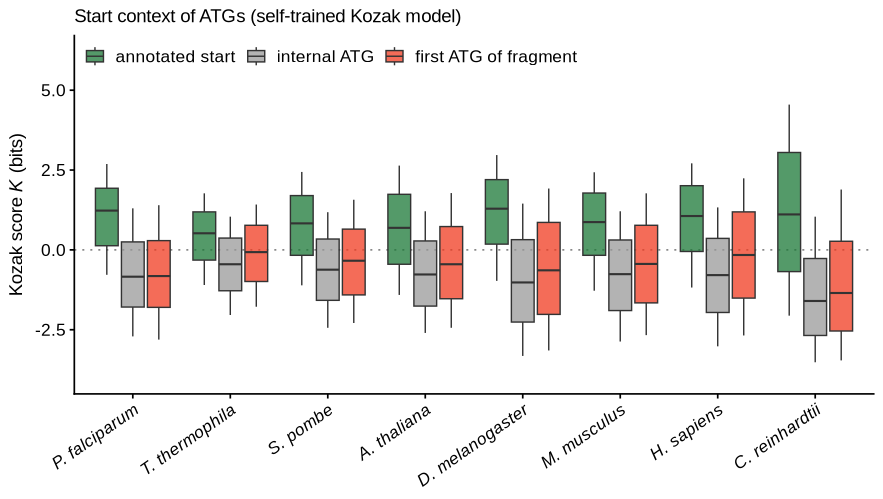

```r
SETS <- c(true_start = "annotated start", internal_ATG = "internal ATG", frag_firstATG = "first ATG of fragment")
SET_COL <- c(true_start = "#1b7837", internal_ATG = "#999999", frag_firstATG = FRAG_C)
d_dat <- kd %>% filter(set %in% names(SETS)) %>% mutate(set = factor(set, levels = names(SETS)))
p3d <- ggplot(d_dat, aes(x = org, fill = set)) +
  geom_hline(yintercept = 0, colour = "#888888", linewidth = 0.3, linetype = "dotted") +
  geom_boxplot(aes(ymin = p10, lower = p25, middle = p50, upper = p75, ymax = p90), stat = "identity",
               position = position_dodge(width = 0.8), width = 0.7, linewidth = 0.25, alpha = 0.75,
               fatten = 1.5) +
  scale_fill_manual(values = SET_COL, labels = SETS, name = NULL) +
  scale_x_discrete(labels = ORG_LABEL) +
  scale_y_continuous(limits = c(-4, 6.2)) +
  labs(x = NULL, y = expression("Kozak score " * italic(K) * " (bits)"),
       title = "Start context of ATGs (self-trained Kozak model)") +
  theme(axis.text.x = element_text(face = "italic", angle = 35, hjust = 1),
        legend.position = c(0, 1), legend.justification = c(0, 1), legend.direction = "horizontal")
p3d
```

**Fig. 3d values**

```r
kable(d_dat %>% select(org, set, p10, p25, p50, p75, p90))
```

| org | set | p10 | p25 | p50 | p75 | p90 |
| --- | --- | --- | --- | --- | --- | --- |
| pfalciparum | frag_firstATG | -2.81 | -1.80 | -0.82 | 0.29 | 1.40 |
| pfalciparum | internal_ATG | -2.71 | -1.79 | -0.84 | 0.25 | 1.30 |
| pfalciparum | true_start | -0.78 | 0.13 | 1.23 | 1.93 | 2.69 |
| tthermophila | frag_firstATG | -1.78 | -0.99 | -0.07 | 0.77 | 1.42 |
| tthermophila | internal_ATG | -2.04 | -1.28 | -0.45 | 0.37 | 1.04 |
| tthermophila | true_start | -1.10 | -0.32 | 0.52 | 1.19 | 1.77 |
| spombe | frag_firstATG | -2.29 | -1.41 | -0.34 | 0.65 | 1.57 |
| spombe | internal_ATG | -2.44 | -1.58 | -0.62 | 0.34 | 1.18 |
| spombe | true_start | -1.11 | -0.17 | 0.83 | 1.70 | 2.44 |
| athal | frag_firstATG | -2.44 | -1.53 | -0.45 | 0.73 | 1.78 |
| athal | internal_ATG | -2.60 | -1.76 | -0.77 | 0.28 | 1.21 |
| athal | true_start | -1.41 | -0.45 | 0.69 | 1.74 | 2.64 |
| dmel | frag_firstATG | -3.15 | -2.02 | -0.64 | 0.86 | 1.92 |
| dmel | internal_ATG | -3.32 | -2.26 | -1.02 | 0.32 | 1.45 |
| dmel | true_start | -0.97 | 0.18 | 1.29 | 2.20 | 2.97 |
| mouse | frag_firstATG | -2.67 | -1.66 | -0.44 | 0.77 | 1.77 |
| mouse | internal_ATG | -2.87 | -1.90 | -0.76 | 0.31 | 1.21 |
| mouse | true_start | -1.28 | -0.17 | 0.87 | 1.78 | 2.43 |
| human | frag_firstATG | -2.68 | -1.51 | -0.16 | 1.19 | 2.24 |
| human | internal_ATG | -3.02 | -1.96 | -0.79 | 0.36 | 1.33 |
| human | true_start | -1.18 | -0.05 | 1.06 | 2.01 | 2.71 |
| creinhardtii | frag_firstATG | -3.46 | -2.54 | -1.35 | 0.27 | 1.89 |
| creinhardtii | internal_ATG | -3.52 | -2.68 | -1.60 | -0.27 | 1.04 |
| creinhardtii | true_start | -2.06 | -0.68 | 1.11 | 3.05 | 4.55 |

### Later ATGs chosen by start context

`pytd_dev_pwm` (ATG chosen by the PWM) against `pytd_dev` (first in-frame ATG), complete inputs (`summary.tsv`).

```r
pwm <- summ %>% filter(variant == "complete", tool %in% c("pytd_dev", "pytd_dev_pwm")) %>%
  select(org, tool, tp_exact, f1_exact) %>%
  pivot_wider(names_from = tool, values_from = c(tp_exact, f1_exact)) %>%
  mutate(diff_points = pts(f1_exact_pytd_dev_pwm - f1_exact_pytd_dev),
         diff_tp = tp_exact_pytd_dev_pwm - tp_exact_pytd_dev)
kable(pwm, digits = 4)
```

| org | tp_exact_pytd_dev | tp_exact_pytd_dev_pwm | f1_exact_pytd_dev | f1_exact_pytd_dev_pwm | diff_points | diff_tp |
| --- | --- | --- | --- | --- | --- | --- |
| athal | 23092 | 22855 | 0.8841 | 0.8750 | -0.91 | -237 |
| creinhardtii | 12592 | 12661 | 0.7400 | 0.7441 | 0.41 | 69 |
| dmel | 12197 | 12147 | 0.9075 | 0.9038 | -0.37 | -50 |
| human | 16841 | 16636 | 0.8902 | 0.8793 | -1.09 | -205 |
| mouse | 18920 | 18886 | 0.8967 | 0.8950 | -0.17 | -34 |
| pfalciparum | 4823 | 4824 | 0.9283 | 0.9285 | 0.02 | 1 |
| spombe | 4496 | 4483 | 0.9045 | 0.9019 | -0.26 | -13 |
| tthermophila | 21439 | 21250 | 0.8369 | 0.8295 | -0.74 | -189 |

```r
n_not_improved <- sum(pwm$diff_points <= 0.05)
```

The PWM choice was lower in 6 organisms, higher by 1 exact match in *P. falciparum* (+0.02 points) and higher in *C. reinhardtii* (+0.41 points). Counting changes of at most 0.05 points as no improvement, it did not improve accuracy in 7 of 8.

### Parameter grid

```r
plat_cells <- both %>% filter(mean_f1 >= both$mean_f1[both$config == "a0.4_w25"] - 0.005)
plat_alpha <- range(plat_cells$alpha); plat_w <- range(plat_cells$weight)
w_range_bits <- range(W_NATS) * log(2)
kz_every <- pl %>% filter(weight %in% c(0, 25)) %>%
  select(input, alpha, weight, mean_f1) %>%
  pivot_wider(names_from = weight, values_from = mean_f1, names_prefix = "w") %>%
  mutate(kozak_gain = pts(w25 - w0))
kz_at04 <- kz_every %>% filter(alpha == 0.4)
flat <- both %>% filter(alpha == 0.4, weight %in% c(10, 25, 50))
kable(plat_cells %>% select(config, alpha, weight, mean_f1), digits = 4,
      caption = "Cells within 0.5 points of the default (mean of both)")
```

Cells within 0.5 points of the default (mean of both)

| config | alpha | weight | mean_f1 |
| --- | --- | --- | --- |
| a0.4_w25 | 0.4 | 25 | 0.8322 |
| a0.3_w25 | 0.3 | 25 | 0.8317 |
| a0.5_w25 | 0.5 | 25 | 0.8298 |
| a0.4_w10 | 0.4 | 10 | 0.8297 |
| a0.2_w25 | 0.2 | 25 | 0.8291 |
| a0.3_w10 | 0.3 | 10 | 0.8290 |
| a0.4_w50 | 0.4 | 50 | 0.8282 |
| a0.3_w50 | 0.3 | 50 | 0.8281 |

```r
kable(kz_every %>% pivot_wider(id_cols = alpha, names_from = input, values_from = kozak_gain), digits = 2,
      caption = "Kozak term (w 25 per nat minus w 0), mean exact F1 points, by alpha")
```

Kozak term (w 25 per nat minus w 0), mean exact F1 points, by alpha

| alpha | complete | fragments | both |
| --- | --- | --- | --- |
| 0.00 | 3.11 | 1.48 | 2.30 |
| 0.10 | 2.24 | 2.21 | 2.22 |
| 0.20 | 1.60 | 2.15 | 1.88 |
| 0.30 | 1.08 | 2.34 | 1.72 |
| 0.40 | 0.62 | 2.68 | 1.66 |
| 0.50 | 0.21 | 3.10 | 1.65 |
| 0.60 | -0.04 | 3.72 | 1.85 |
| 0.80 | -0.36 | 5.05 | 2.35 |
| 1.00 | -0.44 | 5.90 | 2.73 |
| 1.25 | -0.52 | 6.22 | 2.85 |
| 1.50 | -0.49 | 5.96 | 2.74 |
| 2.00 | -0.38 | 4.58 | 2.10 |
| 3.00 | -0.24 | 2.64 | 1.20 |

```r
check_text("methods L245: mu min (complete)", round(min(muc$mu_per_base), 3), 0.063)
check_text("methods L245: mu max (complete)", round(max(muc$mu_per_base), 3), 0.136)
check_text("methods L267: worked example baseline", 0.4 * 90, 36)
check_text("methods L268: worked example K=+1", 0.4 * 90 + 17, 53)
check_text("methods L268: worked example K=-1", 0.4 * 90 - 17, 19)
check_text("methods L278: true start median min (bits)", round(min(ts$p50), 1), 0.5)
check_text("methods L278: true start median max (bits)", round(max(ts$p50), 1), 1.3)
check_text("methods L278: internal ATG median, highest (bits; -0.45 rounds either way)", max(ia$p50), -0.5, tol = 0.051)
check_text("methods L278: internal ATG median, lowest (bits)", round(min(ia$p50), 1), -1.6)
check_text("methods L280: later ATG by context, no improvement (n orgs)", n_not_improved, 7)
check_text("methods L284: grid values", nrow(both), 78)
check_text("methods L284: alpha max", max(ALPHAS), 3)
check_text("methods L284: w max per bit", round(max(W_NATS) * log(2)), 69)
check_text("methods L290: cells within 0.5 pt", nrow(plat_cells), 8)
check_text("methods L290: plateau alpha min", plat_alpha[1], 0.2)
check_text("methods L290: plateau alpha max", plat_alpha[2], 0.5)
check_text("methods L290: plateau w min per bit", round(plat_w[1] * log(2)), 7)
check_text("methods L290: plateau w max per bit", round(plat_w[2] * log(2)), 35)
check_text("methods L291: LOO folds choosing default", sum(loo_both$chosen == "a0.4_w25"), 7)
check_text("methods L291: Kozak improved at every alpha (both)", as.numeric(all(kz_every$kozak_gain[kz_every$input == "both"] > 0)), 1)
check_text("methods L292: Kozak term at 0.4, complete (pts)", round(kz_at04$kozak_gain[kz_at04$input == "complete"], 1), 0.6)
check_text("methods L293: Kozak term at 0.4, fragments (pts)", round(kz_at04$kozak_gain[kz_at04$input == "fragments"], 1), 2.7)
```

E13, E09, E25

## Figure 3

Panel b plots exact F1 per organism without refinement, with v6.0.0, at α 0.4 with $w=0$ and at the grid default (all from the controlled comparison, with v6.0.0 from `summary.tsv`). The release run (`pytd_v7`) is added as a fifth marker (diamond), as described in the caption (`figures_main.tex`).

```r
MARK_LAB <- c(norefine = "no refinement", v600 = "v6.0.0", w0 = "α 0.4, w 0 (no Kozak term)",
              final = "α 0.4, w 17 per bit (grid)", release = "release (v7)")
MARK_SHAPE <- c(norefine = 21, v600 = 22, w0 = 24, final = 21, release = 23)
MARK_FILL <- c(norefine = "white", v600 = "#bbbbbb", w0 = "white", final = TD_C, release = "#fdae61")
MARK_COL <- c(norefine = "#444444", v600 = "#777777", w0 = TD_C, final = TD_C, release = "#7f3b08")
b_dat <- f1 %>% select(org, input, norefine, v600, w0, final, release) %>%
  pivot_longer(c(norefine, v600, w0, final, release), names_to = "marker", values_to = "f1") %>%
  mutate(y = match(org, org_rev) - 1, marker = factor(marker, levels = names(MARK_LAB)))
panel_b <- function(inp, show_y, xlim) {
  d <- b_dat %>% filter(input == inp)
  rng <- d %>% group_by(org, y) %>% summarise(lo = min(f1), hi = max(f1), .groups = "drop")
  arr <- f1 %>% filter(input == inp) %>% mutate(y = match(org, org_rev) - 1)
  ggplot() +
    geom_segment(data = rng, aes(x = lo, xend = hi, y = y, yend = y), colour = "#cccccc", linewidth = 0.3) +
    geom_segment(data = arr, aes(x = norefine, xend = final, y = y, yend = y), colour = TD_C, alpha = 0.35,
                 linewidth = 0.7) +
    geom_point(data = d, aes(f1, y, shape = marker, fill = marker, colour = marker), size = 1.4, stroke = 0.4) +
    scale_shape_manual(values = MARK_SHAPE, labels = MARK_LAB, name = NULL) +
    scale_fill_manual(values = MARK_FILL, labels = MARK_LAB, name = NULL) +
    scale_colour_manual(values = MARK_COL, labels = MARK_LAB, name = NULL) +
    scale_y_continuous(breaks = seq_along(org_rev) - 1, labels = if (show_y) ORG_LABEL[org_rev] else NULL,
                       expand = c(0.04, 0)) +
    scale_x_continuous(limits = xlim) +
    labs(x = "exact-CDS F1", y = NULL, title = inp) +
    theme(axis.text.y = element_text(face = "italic"), axis.ticks.y = element_blank(),
          panel.grid.major.x = element_line(colour = "#eeeeee", linewidth = 0.25),
          plot.title = element_text(colour = ifelse(inp == "complete", COMPLETE_C, FRAG_C)))
}
p3b1 <- panel_b("complete", TRUE, c(0.40, 1.0))
p3b2 <- panel_b("fragments", FALSE, c(0.58, 0.88))
```

**Fig. 3b values**

```r
kable(f1 %>% select(org, input, norefine, v600, w0, final, release), digits = 4)
```

| org | input | norefine | v600 | w0 | final | release |
| --- | --- | --- | --- | --- | --- | --- |
| pfalciparum | complete | 0.8978 | 0.9119 | 0.9294 | 0.9284 | 0.9404 |
| pfalciparum | fragments | 0.8484 | 0.7882 | 0.7910 | 0.8059 | 0.8682 |
| tthermophila | complete | 0.4524 | 0.5673 | 0.8379 | 0.8398 | 0.8334 |
| tthermophila | fragments | 0.6477 | 0.6215 | 0.7490 | 0.7620 | 0.7594 |
| spombe | complete | 0.7182 | 0.7806 | 0.9121 | 0.9119 | 0.9163 |
| spombe | fragments | 0.7762 | 0.7146 | 0.7647 | 0.7845 | 0.8295 |
| athal | complete | 0.6816 | 0.7768 | 0.8875 | 0.8966 | 0.8992 |
| athal | fragments | 0.7240 | 0.6928 | 0.6885 | 0.7226 | 0.7531 |
| dmel | complete | 0.7541 | 0.8109 | 0.9136 | 0.9220 | 0.9279 |
| dmel | fragments | 0.7854 | 0.7298 | 0.7663 | 0.7944 | 0.8411 |
| mouse | complete | 0.7002 | 0.7938 | 0.9002 | 0.9082 | 0.9070 |
| mouse | fragments | 0.7811 | 0.7398 | 0.7607 | 0.8019 | 0.8180 |
| human | complete | 0.5633 | 0.7546 | 0.8937 | 0.9222 | 0.9199 |
| human | fragments | 0.7257 | 0.7158 | 0.7691 | 0.8124 | 0.8251 |
| creinhardtii | complete | 0.6135 | 0.6697 | 0.7465 | 0.7415 | 0.7469 |
| creinhardtii | fragments | 0.7464 | 0.7057 | 0.7401 | 0.7605 | 0.7783 |

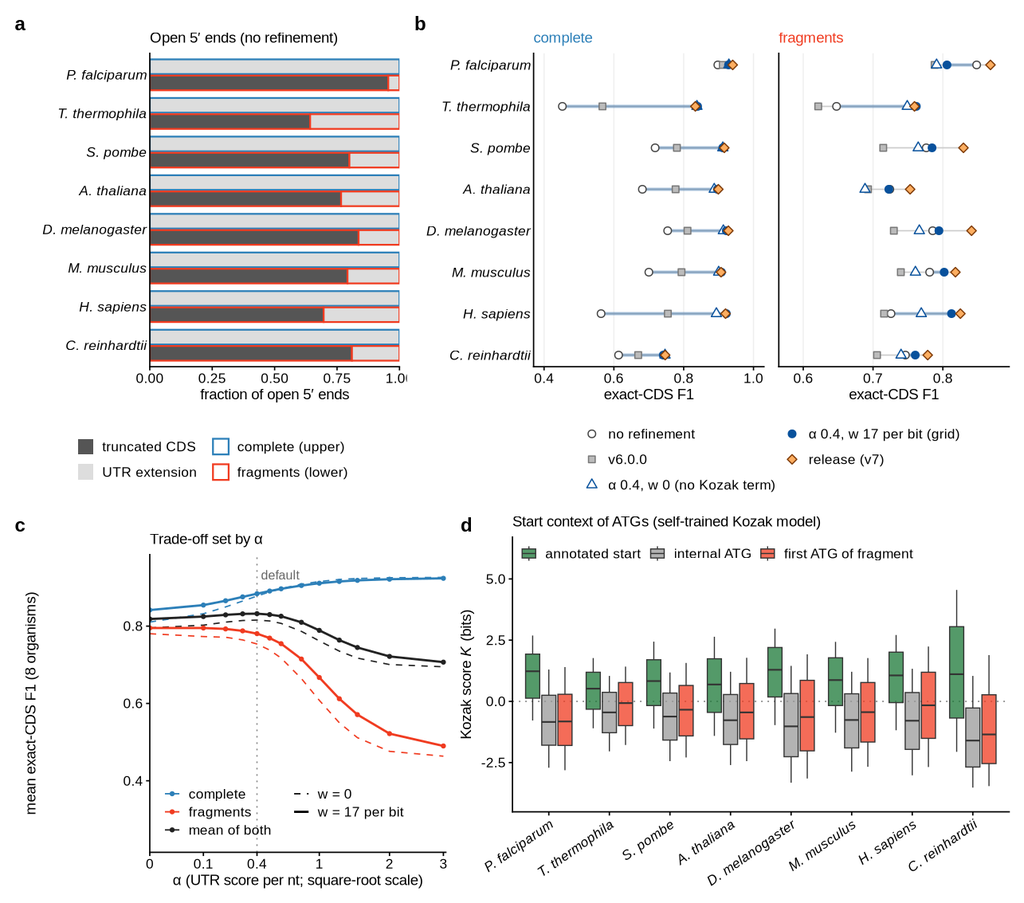

```r
top <- (p3a | (p3b1 + p3b2 + plot_layout(guides = "collect") &
                 theme(legend.position = "bottom") & guides(shape = guide_legend(ncol = 2)))) +
  plot_layout(widths = c(1.05, 2))
bot <- (p3c | wrap_elements(full = p3d)) + plot_layout(widths = c(0.8, 1.45))
fig3 <- (top / bot) + plot_layout(heights = c(1, 0.95)) +
  plot_annotation(tag_levels = list(c("a", "b", "", "c", "d")))
save_fig(fig3, "fig3_start", width = FULL_W, height = 150 / 25.4)
fig3
```

## Supplementary Fig. S1: Kozak logos

Self-trained (release `pytd_v7` runs, upper logo of each pair) and annotation-trained (lower) log2-odds logos. Letters above the axis are favoured at start codons, letters below are depleted, compared with internal in-frame ATGs. Letters are drawn as polygons (ggseqlogo is not installed). The logos are the content of `figures/kozak/kozak_logos_self_vs_truth`, with the release self-trained models; the organisms are in the shared order (by G+C).

```r
# Letter outlines in a unit box (x 0-1, y 0-1); 'sub' marks holes (A).
arc <- function(t0, t1, rx, ry, n = 40) {
  t <- seq(t0, t1, length.out = n) * pi / 180
  tibble(x = 0.5 + rx * cos(t), y = 0.5 + ry * sin(t))
}
ring <- function(t0, t1) bind_rows(arc(t0, t1, 0.5, 0.5), arc(t1, t0, 0.28, 0.3)) %>% rename(gx = x, gy = y)
GLYPHS <- bind_rows(
  tibble(base = "A", part = 1, sub = 1, gx = c(0, 0.38, 0.62, 1, 0.76, 0.67, 0.33, 0.24),
         gy = c(0, 1, 1, 0, 0, 0.27, 0.27, 0)),
  tibble(base = "A", part = 1, sub = 2, gx = c(0.39, 0.61, 0.5), gy = c(0.44, 0.44, 0.76)),
  ring(45, 315) %>% mutate(base = "C", part = 1, sub = 1),
  ring(45, 360) %>% mutate(base = "G", part = 1, sub = 1),
  tibble(base = "G", part = 2, sub = 1, gx = c(0.55, 1, 1, 0.55), gy = c(0.4, 0.4, 0.55, 0.55)),
  tibble(base = "T", part = 1, sub = 1, gx = c(0, 1, 1, 0.61, 0.61, 0.39, 0.39, 0),
         gy = c(1, 1, 0.82, 0.82, 0, 0, 0.82, 0.82))
)
BASE_COL <- c(A = "#109648", C = "#255C99", G = "#F7B32B", T = "#D62839")
XPOS <- c(`-6` = 0, `-5` = 1, `-4` = 2, `-3` = 3, `-2` = 4, `-1` = 5, `+4` = 9, `+5` = 10)
XLABELS <- c("-6", "-5", "-4", "-3", "-2", "-1", "A", "T", "G", "+4", "+5")

# Stack the log2-odds of one model: positive values upward (largest on top), negative downward.
logo_stacks <- function(m) {
  m %>% mutate(x = XPOS[position]) %>% group_by(position) %>%
    mutate(sign = ifelse(log2odds > 0, 1, -1), h = abs(log2odds)) %>%
    filter(h > 0) %>% arrange(sign, h, .by_group = TRUE) %>% group_by(position, sign) %>%
    mutate(y1 = cumsum(h), y0 = y1 - h) %>% ungroup() %>%
    mutate(ybot = ifelse(sign > 0, y0, -y1))
}
logo_plot <- function(m, lim, title) {
  st <- logo_stacks(m) %>% mutate(letter = row_number())
  poly <- st %>% inner_join(GLYPHS, by = "base", relationship = "many-to-many") %>%
    mutate(px = x - 0.45 + 0.9 * gx, py = ybot + h * gy,
           grp = paste(letter, part)) %>% select(px, py, grp, sub, base)
  ggplot(poly) +
    annotate("rect", xmin = 5.5, xmax = 8.5, ymin = -Inf, ymax = Inf, fill = "#f2f2f2") +
    geom_hline(yintercept = 0, linewidth = 0.3) +
    geom_polygon(aes(px, py, group = grp, subgroup = sub, fill = base), colour = NA) +
    scale_fill_manual(values = BASE_COL, guide = "none") +
    scale_x_continuous(breaks = 0:10, labels = XLABELS, limits = c(-0.6, 10.6), expand = c(0, 0)) +
    scale_y_continuous(limits = c(-lim, lim)) +
    labs(x = NULL, y = "log2-odds", title = title) +
    theme(axis.text.x = element_text(size = 5.5, colour = c(rep("black", 6), rep("#888888", 3), rep("black", 2))),
          plot.title = element_text(size = 6.5))
}
```

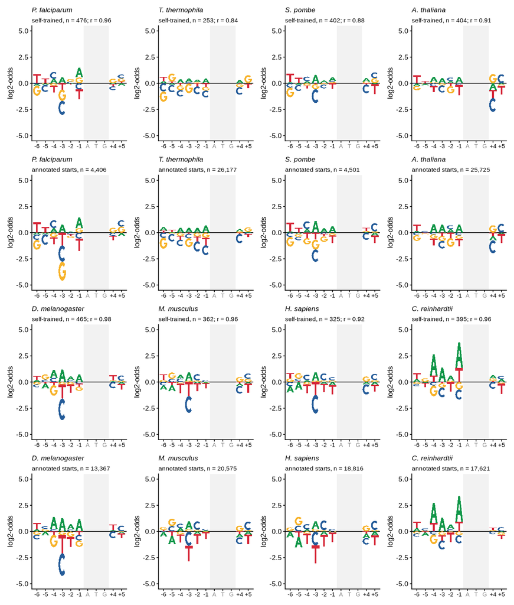

```r
ext <- kmod %>% mutate(sign = log2odds > 0) %>% group_by(org, model, position, sign) %>%
  summarise(s = sum(abs(log2odds)), .groups = "drop")
lim <- ceiling(max(ext$s) * 2) / 2
logos <- list()
for (k in seq_along(ORGS)) {
  o <- ORGS[k]
  ks <- kstat %>% filter(org == o)
  for (mdl in c("self", "truth")) {
    m <- kmod %>% filter(org == o, model == mdl)
    sub <- if (mdl == "self") {
      sprintf("self-trained, n = %s; r = %.2f", format(ks$n_self, big.mark = ","), ks$pearson_self_truth)
    } else {
      sprintf("annotated starts, n = %s", format(ks$n_truth, big.mark = ","))
    }
    ttl <- bquote(italic(.(ORG_LABEL[[o]])))
    logos[[paste(o, mdl)]] <- logo_plot(m, lim, ttl) + labs(subtitle = sub) +
      theme(plot.subtitle = element_text(size = 5.8, margin = margin(0, 0, 2, 0)))
  }
}
# 4 columns: organisms 1-4 in rows 1-2 (self, annotated), organisms 5-8 in rows 3-4
ord <- c(sapply(list(1:4, 5:8), function(ix) c(paste(ORGS[ix], "self"), paste(ORGS[ix], "truth"))))
figS1 <- wrap_plots(logos[ord], ncol = 4)
save_fig(figS1, "figS1_kozak_logos", width = FULL_W, height = 200 / 25.4)
figS1
```

**Fig. S1 values (log2-odds)**

```r
kable(kmod %>% select(org, model, position, base, start_count, internal_count, log2odds) %>%
        pivot_wider(id_cols = c(org, model, position), names_from = base, values_from = log2odds), digits = 3)
```

| org | model | position | A | C | G | T |
| --- | --- | --- | --- | --- | --- | --- |
| pfalciparum | self | -6 | -0.164 | -0.070 | -0.953 | 0.887 |
| pfalciparum | self | -5 | -0.128 | -0.671 | -0.027 | 0.468 |
| pfalciparum | self | -4 | 0.426 | 0.656 | -0.238 | -0.640 |
| pfalciparum | self | -3 | 0.581 | -1.334 | -1.080 | -0.602 |
| pfalciparum | self | -2 | -0.043 | 0.138 | 0.262 | -0.056 |
| pfalciparum | self | -1 | 0.936 | -0.583 | 0.557 | -0.946 |
| pfalciparum | self | +4 | -0.070 | -0.349 | 0.437 | -0.230 |
| pfalciparum | self | +5 | -0.219 | 0.364 | 0.323 | 0.146 |
| pfalciparum | truth | -6 | -0.175 | -0.510 | -0.941 | 1.000 |
| pfalciparum | truth | -5 | -0.126 | -1.010 | -0.025 | 0.524 |
| pfalciparum | truth | -4 | 0.434 | 0.755 | -0.451 | -0.653 |
| pfalciparum | truth | -3 | 0.776 | -1.556 | -1.813 | -1.222 |
| pfalciparum | truth | -2 | 0.101 | -0.144 | -0.219 | -0.149 |
| pfalciparum | truth | -1 | 1.027 | -0.560 | 0.426 | -1.214 |
| pfalciparum | truth | +4 | -0.032 | -0.264 | 0.464 | -0.418 |
| pfalciparum | truth | +5 | -0.274 | 0.600 | 0.585 | -0.042 |
| tthermophila | self | -6 | 0.201 | -0.781 | -0.980 | 0.405 |
| tthermophila | self | -5 | -0.164 | -0.691 | 0.767 | 0.160 |
| tthermophila | self | -4 | 0.376 | -0.608 | -0.453 | -0.201 |
| tthermophila | self | -3 | 0.339 | 0.115 | -0.921 | -0.021 |
| tthermophila | self | -2 | 0.261 | -0.746 | 0.100 | -0.293 |
| tthermophila | self | -1 | 0.454 | -0.650 | -0.362 | -0.337 |
| tthermophila | self | +4 | 0.322 | -0.725 | -0.313 | -0.054 |
| tthermophila | self | +5 | -0.023 | 0.011 | 0.761 | -0.419 |
| tthermophila | truth | -6 | 0.322 | -0.485 | -1.043 | 0.213 |
| tthermophila | truth | -5 | 0.058 | -0.712 | -0.122 | 0.226 |
| tthermophila | truth | -4 | 0.463 | -0.583 | -0.333 | -0.349 |
| tthermophila | truth | -3 | 0.463 | -0.433 | -0.833 | -0.109 |
| tthermophila | truth | -2 | 0.458 | -0.970 | -0.377 | -0.456 |
| tthermophila | truth | -1 | 0.686 | -0.932 | -0.487 | -0.722 |

[output cut: 98 more lines]

E09, E25

## Supplementary Fig. S2: α × w grid

1. Mean exact F1 (×100) over the eight benchmark organisms. (b) GM12878 assemblies (×100) (`gm12878.tsv`, E13): exact recovery of fully assembled MANE CDSs and the exact-start share of GENCODE-compatible complete calls (×100). Colour spans the best value to 5 points below it; bold, best value; red box, default. There is no release-code equivalent of this grid; it is the development grid (E13).

```r
heat <- function(d, title) {
  hi <- max(d$v); lo <- max(min(d$v), hi - 5)
  d <- d %>% mutate(frac = (v - lo) / (hi - lo), best = v == hi)
  ggplot(d, aes(x, y)) +
    geom_tile(aes(fill = v)) +
    geom_text(aes(label = sprintf("%.1f", v), colour = frac > 0.6, fontface = ifelse(best, "bold", "plain")),
              size = 1.9) +
    geom_tile(data = d %>% filter(default), fill = NA, colour = "#e41a1c", linewidth = 0.5) +
    scale_fill_distiller(palette = "Blues", direction = 1, limits = c(lo, hi), oob = scales::squish, guide = "none") +
    scale_colour_manual(values = c(`TRUE` = "white", `FALSE` = "black"), guide = "none") +
    scale_x_discrete(expand = c(0, 0)) + scale_y_discrete(expand = c(0, 0)) +
    labs(x = "Kozak weight w (per bit)", y = "α", title = title) +
    theme(axis.line = element_blank(), axis.ticks = element_blank())
}
```

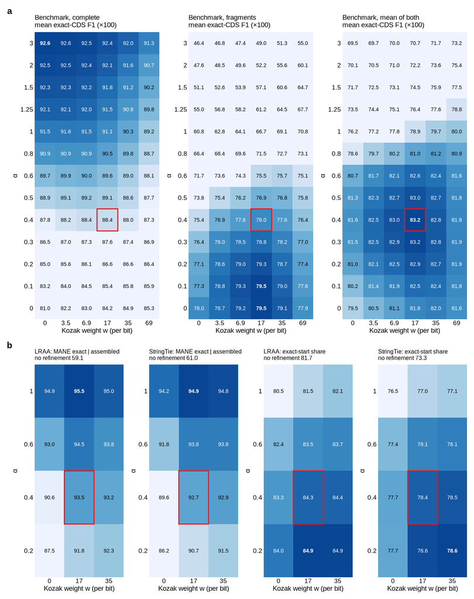

```r
TITLES <- c(complete = "Benchmark, complete", fragments = "Benchmark, fragments", both = "Benchmark, mean of both")
s2a_dat <- plateau %>%
  mutate(v = 100 * mean_f1, x = factor(w_bits(weight), levels = w_bits(W_NATS)),
         y = factor(format(alpha, drop0trailing = TRUE, trim = TRUE), levels = format(ALPHAS, drop0trailing = TRUE, trim = TRUE)),
         default = config == "a0.4_w25")
s2a <- lapply(names(TITLES), function(i)
  heat(s2a_dat %>% filter(input == i), paste0(TITLES[[i]], "\nmean exact-CDS F1 (×100)")))
GA <- c("0.2", "0.4", "0.6", "1.0"); GW <- c(0, 25, 50)
METRICS <- c(MANE_sens_exact_given_assembled = "MANE exact | assembled",
             pred_complete_start_precision = "exact-start share")
s2b_dat <- gm %>% filter(config != "norefine") %>%
  pivot_longer(names(METRICS), names_to = "metric", values_to = "val") %>%
  mutate(v = 100 * val, x = factor(w_bits(weight), levels = w_bits(GW)),
         y = factor(formatC(alpha, format = "f", digits = 1), levels = GA),
         default = config == "a0.4_w25")
nr <- gm %>% filter(config == "norefine")
s2b <- list()
for (mt in names(METRICS)) for (asm in c("lraa", "stringtie")) {
  nrv <- 100 * nr[[mt]][nr$assembly == asm]
  s2b[[paste(mt, asm)]] <- heat(s2b_dat %>% filter(metric == mt, assembly == asm) %>%
                                  mutate(y = factor(sub("\\.0$", "", as.character(y)), levels = c("0.2", "0.4", "0.6", "1"))),
                                paste0(ifelse(asm == "lraa", "LRAA", "StringTie"), ": ", METRICS[[mt]],
                                       "\nno refinement ", sprintf("%.1f", nrv))) +
    theme(plot.title = element_text(size = 6))
}
figS2 <- (wrap_plots(s2a, ncol = 3) / wrap_plots(s2b, ncol = 4)) + plot_layout(heights = c(1.35, 1)) +
  plot_annotation(tag_levels = list(c("a", "", "", "b", "", "", "")))
save_fig(figS2, "figS2_start_grid", width = FULL_W, height = 215 / 25.4)
figS2
```

**Fig. S2 values**

```r
kable(s2a_dat %>% select(input, alpha, weight_per_nat = weight, w_per_bit = x, value = v), digits = 2)
```

| input | alpha | weight_per_nat | w_per_bit | value |
| --- | --- | --- | --- | --- |
| complete | 0.00 | 0 | 0 | 81.05 |
| complete | 0.00 | 5 | 3.5 | 82.20 |
| complete | 0.00 | 10 | 6.9 | 82.96 |
| complete | 0.00 | 25 | 17 | 84.16 |
| complete | 0.00 | 50 | 35 | 84.94 |
| complete | 0.00 | 100 | 69 | 85.34 |
| complete | 0.10 | 0 | 0 | 83.20 |
| complete | 0.10 | 5 | 3.5 | 83.95 |
| complete | 0.10 | 10 | 6.9 | 84.54 |
| complete | 0.10 | 25 | 17 | 85.44 |
| complete | 0.10 | 50 | 35 | 85.84 |
| complete | 0.10 | 100 | 69 | 85.89 |
| complete | 0.20 | 0 | 0 | 84.96 |
| complete | 0.20 | 5 | 3.5 | 85.61 |
| complete | 0.20 | 10 | 6.9 | 86.05 |
| complete | 0.20 | 25 | 17 | 86.56 |
| complete | 0.20 | 50 | 35 | 86.63 |
| complete | 0.20 | 100 | 69 | 86.40 |
| complete | 0.30 | 0 | 0 | 86.48 |
| complete | 0.30 | 5 | 3.5 | 87.03 |
| complete | 0.30 | 10 | 6.9 | 87.32 |
| complete | 0.30 | 25 | 17 | 87.56 |
| complete | 0.30 | 50 | 35 | 87.39 |
| complete | 0.30 | 100 | 69 | 86.85 |
| complete | 0.40 | 0 | 0 | 87.76 |
| complete | 0.40 | 5 | 3.5 | 88.17 |
| complete | 0.40 | 10 | 6.9 | 88.36 |
| complete | 0.40 | 25 | 17 | 88.38 |
| complete | 0.40 | 50 | 35 | 88.03 |
| complete | 0.40 | 100 | 69 | 87.29 |

[output cut: 204 more lines]

```r
kable(s2b_dat %>% select(assembly, metric, alpha, weight_per_nat = weight, value = v) %>%
        bind_rows(nr %>% pivot_longer(names(METRICS), names_to = "metric", values_to = "val") %>%
                    transmute(assembly, metric, alpha = NA, weight_per_nat = NA, value = 100 * val)), digits = 2)
```

| assembly | metric | alpha | weight_per_nat | value |
| --- | --- | --- | --- | --- |
| lraa | MANE_sens_exact_given_assembled | 0.2 | 0 | 87.48 |
| lraa | pred_complete_start_precision | 0.2 | 0 | 83.97 |
| lraa | MANE_sens_exact_given_assembled | 0.2 | 25 | 91.80 |
| lraa | pred_complete_start_precision | 0.2 | 25 | 84.86 |
| lraa | MANE_sens_exact_given_assembled | 0.2 | 50 | 92.26 |
| lraa | pred_complete_start_precision | 0.2 | 50 | 84.85 |
| lraa | MANE_sens_exact_given_assembled | 0.4 | 0 | 90.63 |
| lraa | pred_complete_start_precision | 0.4 | 0 | 83.26 |
| lraa | MANE_sens_exact_given_assembled | 0.4 | 25 | 93.45 |
| lraa | pred_complete_start_precision | 0.4 | 25 | 84.34 |
| lraa | MANE_sens_exact_given_assembled | 0.4 | 50 | 93.18 |
| lraa | pred_complete_start_precision | 0.4 | 50 | 84.35 |
| lraa | MANE_sens_exact_given_assembled | 0.6 | 0 | 92.99 |
| lraa | pred_complete_start_precision | 0.6 | 0 | 82.39 |
| lraa | MANE_sens_exact_given_assembled | 0.6 | 25 | 94.47 |
| lraa | pred_complete_start_precision | 0.6 | 25 | 83.50 |
| lraa | MANE_sens_exact_given_assembled | 0.6 | 50 | 93.84 |
| lraa | pred_complete_start_precision | 0.6 | 50 | 83.66 |
| lraa | MANE_sens_exact_given_assembled | 1.0 | 0 | 94.90 |
| lraa | pred_complete_start_precision | 1.0 | 0 | 80.46 |
| lraa | MANE_sens_exact_given_assembled | 1.0 | 25 | 95.47 |
| lraa | pred_complete_start_precision | 1.0 | 25 | 81.46 |
| lraa | MANE_sens_exact_given_assembled | 1.0 | 50 | 95.04 |
| lraa | pred_complete_start_precision | 1.0 | 50 | 82.06 |
| stringtie | MANE_sens_exact_given_assembled | 0.2 | 0 | 86.24 |
| stringtie | pred_complete_start_precision | 0.2 | 0 | 77.67 |
| stringtie | MANE_sens_exact_given_assembled | 0.2 | 25 | 90.69 |
| stringtie | pred_complete_start_precision | 0.2 | 25 | 78.58 |
| stringtie | MANE_sens_exact_given_assembled | 0.2 | 50 | 91.46 |
| stringtie | pred_complete_start_precision | 0.2 | 50 | 78.65 |
| stringtie | MANE_sens_exact_given_assembled | 0.4 | 0 | 89.57 |
| stringtie | pred_complete_start_precision | 0.4 | 0 | 77.68 |
| stringtie | MANE_sens_exact_given_assembled | 0.4 | 25 | 92.70 |
| stringtie | pred_complete_start_precision | 0.4 | 25 | 78.43 |
| stringtie | MANE_sens_exact_given_assembled | 0.4 | 50 | 92.89 |
| stringtie | pred_complete_start_precision | 0.4 | 50 | 78.51 |
| stringtie | MANE_sens_exact_given_assembled | 0.6 | 0 | 91.78 |
| stringtie | pred_complete_start_precision | 0.6 | 0 | 77.42 |
| stringtie | MANE_sens_exact_given_assembled | 0.6 | 25 | 93.79 |
| stringtie | pred_complete_start_precision | 0.6 | 25 | 78.07 |
| stringtie | MANE_sens_exact_given_assembled | 0.6 | 50 | 93.78 |
| stringtie | pred_complete_start_precision | 0.6 | 50 | 78.14 |
| stringtie | MANE_sens_exact_given_assembled | 1.0 | 0 | 94.17 |
| stringtie | pred_complete_start_precision | 1.0 | 0 | 76.48 |
| stringtie | MANE_sens_exact_given_assembled | 1.0 | 25 | 94.92 |
| stringtie | pred_complete_start_precision | 1.0 | 25 | 76.98 |
| stringtie | MANE_sens_exact_given_assembled | 1.0 | 50 | 94.76 |
| stringtie | pred_complete_start_precision | 1.0 | 50 | 77.14 |
| lraa | MANE_sens_exact_given_assembled | NA | NA | 59.06 |
| lraa | pred_complete_start_precision | NA | NA | 81.67 |
| stringtie | MANE_sens_exact_given_assembled | NA | NA | 61.03 |
| stringtie | pred_complete_start_precision | NA | NA | 73.27 |

E13

## Checks against the manuscript

`results L..` refers to `results_start_refinement.tex`, `methods L..` to `methods_algorithm.tex`. Values from the release (`pytd_v7`) are compared with the current text, which quotes the release where a release run exists; grid comparisons stay on the development grid (E13).

```r
check_report()
```

| claim | computed | manuscript | ok |
| --- | --- | --- | --- |
| results L11: open 5’ ends, complete | 41670 | 41670 | TRUE |
| results L11: predictions, complete | 130066 | 130066 | TRUE |
| results L11: open share complete (%) | 32 | 32 | TRUE |
| results L12: UTR-extended, complete | 41127 | 41127 | TRUE |
| results L13: open 5’ ends, fragments | 72056 | 72056 | TRUE |
| results L13: predictions, fragments | 111104 | 111104 | TRUE |
| results L13: open share fragments (%) | 65 | 65 | TRUE |
| results L14: truncated share fragments (%) | 75 | 75 | TRUE |
| results L14: truncated share T. thermophila (%) | 64 | 64 | TRUE |
| results L15: truncated share P. falciparum (%) | 96 | 96 | TRUE |
| methods L287: ‘about three quarters’ truncated (%) | 75 | 75 | TRUE |
| results L21: complete gain min (pts) | 3.1 | 3.1 | TRUE |
| results L21: complete gain max (pts) | 38.7 | 38.7 | TRUE |
| results L21: complete gain median (pts) | 20.1 | 20.1 | TRUE |
| results L21: complete gain positive in all 8 | 8 | 8 | TRUE |
| results L22: T. thermophila no refinement | 0.452 | 0.452 | TRUE |
| results L22: T. thermophila default | 0.84 | 0.84 | TRUE |
| results L22: human no refinement | 0.563 | 0.563 | TRUE |
| results L22: human default | 0.922 | 0.922 | TRUE |
| results L23: fragments effect min (pts) | -4.3 | -4.3 | TRUE |
| results L23: fragments effect max (pts) | 11.4 | 11.4 | TRUE |
| results L23: fragments effect positive (n orgs) | 6 | 6 | TRUE |
| results L24: A. thaliana fragments effect (pts) | -0.1 | -0.1 | TRUE |
| results L24: P. falciparum fragments no refinement | 0.848 | 0.848 | TRUE |
| results L24: P. falciparum fragments default | 0.806 | 0.806 | TRUE |
| results L25: P. falciparum has highest truncated share | 1 | 1 | TRUE |
| results L29: w=0 below no refinement on fragments (n orgs) | 6 | 6 | TRUE |
| results L29: Kozak term fragments min (pts) | 1.3 | 1.3 | TRUE |
| results L29: Kozak term fragments max (pts) | 4.3 | 4.3 | TRUE |
| results L30: Kozak term fragments positive (n orgs) | 8 | 8 | TRUE |

[output cut: 88 more lines]